# INN_Full_code_Project4_Shraddha_Ramesh

## Data Preprocessing

### Dummy Variable Creation

```python
# Create dummy variables for the categorical columns Gender and Geography
df = pd.get_dummies(data,columns=data.select_dtypes(include=["object"]).columns.tolist(), drop_first=True, dtype=float)
```

### Train-validation-test Split

```python
# Create X with all predictor variables and y with the target variable
X = df.drop(['Exited'],axis=1) # All columns except the target variable
y = df['Exited'] # Exited
```

```python
# Splitting data into training, validation and test set

# first we split data into 2 parts, say temporary and test
X_temp, X_test, y_temp, y_test = train_test_split(X, y, test_size = 0.2, random_state = 1, stratify=y)

# then we split the temporary set into train and validation
X_train, X_val, y_train, y_val = train_test_split(X_temp, y_temp, test_size = 0.2, random_state = 1,stratify=y_temp)

print("Shape of train, validation and test set")
print(X_train.shape, X_val.shape, X_test.shape)
```

```
Shape of train, validation and test set
(6400, 11) (1600, 11) (2000, 11)
```

```python
# Checking class balance for whole data, train set, validation set, and test set

print("Target value ratio in y")
print(y.value_counts(1))
print("*" * 80)
print("Target value ratio in y_train")
print(y_train.value_counts(1))
print("*" * 80)
print("Target value ratio in y_val")
print(y_val.value_counts(1))
print("*" * 80)
print("Target value ratio in y_test")
print(y_test.value_counts(1))
print("*" * 80)
```

```
Target value ratio in y
Exited
0    0.7963
1    0.2037
Name: proportion, dtype: float64
Target value ratio in y_train
Exited
0    0.79625
1    0.20375
Name: proportion, dtype: float64
Target value ratio in y_val
Exited
0    0.79625
1    0.20375
Name: proportion, dtype: float64
Target value ratio in y_test
Exited
0    0.7965
1    0.2035
Name: proportion, dtype: float64
```

### Data Normalization

```python
# Creating a StandardScaler to scale all the numeric values to a normal scale to ensure the neural network treats all the features equally during training.
sc = StandardScaler()

# The columns to be scaled are CreditScore, Age, Tenure, Balance, NumOfProducts, HasCrCard, IsActiveMember, EstimatedSalary
# CreditScore, Age, Balance and EstimatedSalary have different ranges and should be scaled. Tenure and NumOfProducts are discrete but is numeric and still needs to be scaled.
# HasCrCard and IsActiveMember are binary so already are between 0 and 1 but scaling could improve the model performance.
cols_list = ['CreditScore','Age','Tenure','Balance','NumOfProducts','HasCrCard','IsActiveMember','EstimatedSalary']

X_train[cols_list] = sc.fit_transform(X_train[cols_list])
X_val[cols_list] = sc.transform(X_val[cols_list])
X_test[cols_list] = sc.transform(X_test[cols_list])
```

#### Utility functions

```python
# Function to create a plot with desired metric like loss and recall
def plot(history, name):
    """
    Function to plot loss/recall

    history: an object which stores the metrics and losses.
    name: can be one of Loss or Recall
    """
    fig, ax = plt.subplots() #Creating a subplot with figure and axes.
    plt.plot(history.history[name]) #Plotting the train recall or train loss
    plt.plot(history.history['val_'+name]) #Plotting the validation recall or validation loss

    plt.title('Model ' + name.capitalize()) #Defining the title of the plot.
    plt.ylabel(name.capitalize()) #Capitalizing the first letter.
    plt.xlabel('Epoch') #Defining the label for the x-axis.
    fig.legend(['Train', 'Validation'], loc="outside right upper") #Defining the legend, loc controls the position of the legend.
```

```python
# Custom confusion matrix function
def make_confusion_matrix(actual_targets, predicted_targets):
    """
    To plot the confusion_matrix with percentages

    actual_targets: actual target (dependent) variable values
    predicted_targets: predicted target (dependent) variable values
    """
    cm = confusion_matrix(actual_targets, predicted_targets)
    labels = np.asarray(
        [
            ["{0:0.0f}".format(item) + "\n{0:.2%}".format(item / cm.flatten().sum())]
            for item in cm.flatten()
        ]
    ).reshape(cm.shape[0], cm.shape[1])

    plt.figure(figsize=(6, 4))
    sns.heatmap(cm, annot=labels, fmt="")
    plt.ylabel("True label")
    plt.xlabel("Predicted label")
```

## Model Building

### Model Evaluation Criterion

In this case we are doing a churn classification problem and the false predictions can be of two types:

1. False positives: When a customer is not going to exit but the model predicted that they would, which may lead to unnecessary retention effort costs.
2. False negatives: When a customer is going to exit but the model predicted that they wouldn't, which translates to potential revenue loss.

The cost to the bank of missing a customer who churned is much greater than if they accidentally mark a customer as going to churn when they aren't. The difference is between losing a customer they didn't mark as risk of churn v/s being overly pessimistic about certain customers. The cost of losing a customer is much higher than spending resources on targeted retention of a few extra customers. Hence, we want to reduce false negatives and will focus on getting the best **Recall**

### Neural Network with SGD Optimizer

```python
#Set variables for easy aggregation of results
train_metric_df = pd.DataFrame(columns=["Recall"])
valid_metric_df = pd.DataFrame(columns=["Recall"])

#Set metric variable to use the same throughout
metric = keras.metrics.Recall()
```

```python
backend.clear_session()
#Fixing the seed for random number generators so that we can ensure we receive the same output everytime
np.random.seed(1)
random.seed(1)
tf.random.set_seed(1)

model_name = "NN with SGD"
```

```python
#Create an initial neural network instance
model_0 = Sequential()

# Adding the input layer with 128 neurons and relu as activation function
model_0.add(Dense(64, activation='relu', input_dim = X_train.shape[1]))

# Adding a hidden layer with 64 neurons and relu as activation function
model_0.add(Dense(32, activation='relu'))

# Output layer with 1 neuron for binary classification
model_0.add(Dense(1, activation = 'sigmoid'))
```

```python
model_0.summary()
```

```
Model: "sequential"
```

```
┏━━━━━━━━━━━━━━━━━━━━━━━━━━━━━━━━━━━━━━┳━━━━━━━━━━━━━━━━━━━━━━━━━━━━━┳━━━━━━━━━━━━━━━━━┓
┃ Layer (type)                         ┃ Output Shape                ┃         Param # ┃
┡━━━━━━━━━━━━━━━━━━━━━━━━━━━━━━━━━━━━━━╇━━━━━━━━━━━━━━━━━━━━━━━━━━━━━╇━━━━━━━━━━━━━━━━━┩
│ dense (Dense)                        │ (None, 64)                  │             768 │
├──────────────────────────────────────┼─────────────────────────────┼─────────────────┤
│ dense_1 (Dense)                      │ (None, 32)                  │           2,080 │
├──────────────────────────────────────┼─────────────────────────────┼─────────────────┤
│ dense_2 (Dense)                      │ (None, 1)                   │              33 │
└──────────────────────────────────────┴─────────────────────────────┴─────────────────┘
```

```
 Total params: 2,881 (11.25 KB)
```

```
 Trainable params: 2,881 (11.25 KB)
```

```
 Non-trainable params: 0 (0.00 B)
```

```python
# Create an SGD Optimizer and compile the model
optimizer = keras.optimizers.SGD()

model_0.compile(loss='binary_crossentropy', optimizer=optimizer, metrics=[metric])
```

```python
start = time.time()
history_0 = model_0.fit(X_train, y_train, validation_data=(X_val,y_val) , batch_size=32, epochs=50)
end=time.time()
```

```
200/200 ━━━━━━━━━━━━━━━━━━━━ 3s 12ms/step - loss: 0.6200 - recall: 0.2192 - val_loss: 0.4930 - val_recall: 0.0000e+00
200/200 ━━━━━━━━━━━━━━━━━━━━ 2s 10ms/step - loss: 0.4797 - recall: 0.0000e+00 - val_loss: 0.4683 - val_recall: 0.0000e+00
200/200 ━━━━━━━━━━━━━━━━━━━━ 2s 7ms/step - loss: 0.4559 - recall: 0.0000e+00 - val_loss: 0.4515 - val_recall: 0.0031
200/200 ━━━━━━━━━━━━━━━━━━━━ 2s 3ms/step - loss: 0.4393 - recall: 0.0055 - val_loss: 0.4384 - val_recall: 0.0215
200/200 ━━━━━━━━━━━━━━━━━━━━ 0s 2ms/step - loss: 0.4262 - recall: 0.0302 - val_loss: 0.4276 - val_recall: 0.0613
200/200 ━━━━━━━━━━━━━━━━━━━━ 0s 2ms/step - loss: 0.4152 - recall: 0.0786 - val_loss: 0.4187 - val_recall: 0.1227
200/200 ━━━━━━━━━━━━━━━━━━━━ 1s 2ms/step - loss: 0.4059 - recall: 0.1196 - val_loss: 0.4109 - val_recall: 0.1718
200/200 ━━━━━━━━━━━━━━━━━━━━ 1s 2ms/step - loss: 0.3976 - recall: 0.1805 - val_loss: 0.4038 - val_recall: 0.1994
200/200 ━━━━━━━━━━━━━━━━━━━━ 1s 2ms/step - loss: 0.3900 - recall: 0.2397 - val_loss: 0.3970 - val_recall: 0.2270
200/200 ━━━━━━━━━━━━━━━━━━━━ 1s 2ms/step - loss: 0.3828 - recall: 0.2694 - val_loss: 0.3909 - val_recall: 0.2607
200/200 ━━━━━━━━━━━━━━━━━━━━ 1s 2ms/step - loss: 0.3761 - recall: 0.2989 - val_loss: 0.3853 - val_recall: 0.3037
200/200 ━━━━━━━━━━━━━━━━━━━━ 1s 2ms/step - loss: 0.3700 - recall: 0.3204 - val_loss: 0.3803 - val_recall: 0.3282
200/200 ━━━━━━━━━━━━━━━━━━━━ 1s 2ms/step - loss: 0.3644 - recall: 0.3304 - val_loss: 0.3758 - val_recall: 0.3436
200/200 ━━━━━━━━━━━━━━━━━━━━ 1s 2ms/step - loss: 0.3594 - recall: 0.3570 - val_loss: 0.3720 - val_recall: 0.3497
200/200 ━━━━━━━━━━━━━━━━━━━━ 0s 2ms/step - loss: 0.3549 - recall: 0.3681 - val_loss: 0.3687 - val_recall: 0.3589
200/200 ━━━━━━━━━━━━━━━━━━━━ 1s 2ms/step - loss: 0.3508 - recall: 0.3840 - val_loss: 0.3658 - val_recall: 0.3620
200/200 ━━━━━━━━━━━━━━━━━━━━ 1s 2ms/step - loss: 0.3472 - recall: 0.4001 - val_loss: 0.3634 - val_recall: 0.3681
200/200 ━━━━━━━━━━━━━━━━━━━━ 1s 2ms/step - loss: 0.3442 - recall: 0.4065 - val_loss: 0.3614 - val_recall: 0.3834
200/200 ━━━━━━━━━━━━━━━━━━━━ 1s 2ms/step - loss: 0.3415 - recall: 0.4109 - val_loss: 0.3596 - val_recall: 0.3865
200/200 ━━━━━━━━━━━━━━━━━━━━ 0s 2ms/step - loss: 0.3392 - recall: 0.4139 - val_loss: 0.3582 - val_recall: 0.3926
200/200 ━━━━━━━━━━━━━━━━━━━━ 1s 3ms/step - loss: 0.3372 - recall: 0.4182 - val_loss: 0.3570 - val_recall: 0.3926
200/200 ━━━━━━━━━━━━━━━━━━━━ 1s 3ms/step - loss: 0.3355 - recall: 0.4243 - val_loss: 0.3560 - val_recall: 0.3957
200/200 ━━━━━━━━━━━━━━━━━━━━ 1s 3ms/step - loss: 0.3340 - recall: 0.4304 - val_loss: 0.3552 - val_recall: 0.3988
200/200 ━━━━━━━━━━━━━━━━━━━━ 1s 2ms/step - loss: 0.3327 - recall: 0.4362 - val_loss: 0.3545 - val_recall: 0.3988
200/200 ━━━━━━━━━━━━━━━━━━━━ 1s 2ms/step - loss: 0.3315 - recall: 0.4414 - val_loss: 0.3540 - val_recall: 0.4018
200/200 ━━━━━━━━━━━━━━━━━━━━ 0s 2ms/step - loss: 0.3305 - recall: 0.4411 - val_loss: 0.3535 - val_recall: 0.4049
200/200 ━━━━━━━━━━━━━━━━━━━━ 1s 2ms/step - loss: 0.3295 - recall: 0.4428 - val_loss: 0.3531 - val_recall: 0.4110
200/200 ━━━━━━━━━━━━━━━━━━━━ 0s 2ms/step - loss: 0.3287 - recall: 0.4447 - val_loss: 0.3528 - val_recall: 0.4202
200/200 ━━━━━━━━━━━━━━━━━━━━ 1s 2ms/step - loss: 0.3279 - recall: 0.4445 - val_loss: 0.3526 - val_recall: 0.4202
200/200 ━━━━━━━━━━━━━━━━━━━━ 1s 2ms/step - loss: 0.3272 - recall: 0.4440 - val_loss: 0.3523 - val_recall: 0.4202
200/200 ━━━━━━━━━━━━━━━━━━━━ 0s 2ms/step - loss: 0.3265 - recall: 0.4501 - val_loss: 0.3521 - val_recall: 0.4233
200/200 ━━━━━━━━━━━━━━━━━━━━ 0s 2ms/step - loss: 0.3259 - recall: 0.4507 - val_loss: 0.3519 - val_recall: 0.4233
200/200 ━━━━━━━━━━━━━━━━━━━━ 1s 2ms/step - loss: 0.3253 - recall: 0.4518 - val_loss: 0.3517 - val_recall: 0.4233
200/200 ━━━━━━━━━━━━━━━━━━━━ 1s 2ms/step - loss: 0.3247 - recall: 0.4460 - val_loss: 0.3515 - val_recall: 0.4233
200/200 ━━━━━━━━━━━━━━━━━━━━ 1s 2ms/step - loss: 0.3242 - recall: 0.4470 - val_loss: 0.3513 - val_recall: 0.4233
200/200 ━━━━━━━━━━━━━━━━━━━━ 1s 2ms/step - loss: 0.3237 - recall: 0.4475 - val_loss: 0.3510 - val_recall: 0.4264
200/200 ━━━━━━━━━━━━━━━━━━━━ 1s 2ms/step - loss: 0.3232 - recall: 0.4441 - val_loss: 0.3509 - val_recall: 0.4264
200/200 ━━━━━━━━━━━━━━━━━━━━ 1s 2ms/step - loss: 0.3228 - recall: 0.4447 - val_loss: 0.3508 - val_recall: 0.4264
200/200 ━━━━━━━━━━━━━━━━━━━━ 1s 2ms/step - loss: 0.3223 - recall: 0.4498 - val_loss: 0.3507 - val_recall: 0.4264
200/200 ━━━━━━━━━━━━━━━━━━━━ 1s 2ms/step - loss: 0.3219 - recall: 0.4498 - val_loss: 0.3506 - val_recall: 0.4264
200/200 ━━━━━━━━━━━━━━━━━━━━ 1s 3ms/step - loss: 0.3214 - recall: 0.4496 - val_loss: 0.3505 - val_recall: 0.4294
200/200 ━━━━━━━━━━━━━━━━━━━━ 1s 3ms/step - loss: 0.3210 - recall: 0.4496 - val_loss: 0.3504 - val_recall: 0.4294
200/200 ━━━━━━━━━━━━━━━━━━━━ 1s 3ms/step - loss: 0.3206 - recall: 0.4431 - val_loss: 0.3504 - val_recall: 0.4294
200/200 ━━━━━━━━━━━━━━━━━━━━ 1s 3ms/step - loss: 0.3202 - recall: 0.4430 - val_loss: 0.3503 - val_recall: 0.4294
200/200 ━━━━━━━━━━━━━━━━━━━━ 1s 3ms/step - loss: 0.3198 - recall: 0.4451 - val_loss: 0.3502 - val_recall: 0.4325
200/200 ━━━━━━━━━━━━━━━━━━━━ 1s 3ms/step - loss: 0.3194 - recall: 0.4484 - val_loss: 0.3500 - val_recall: 0.4325
200/200 ━━━━━━━━━━━━━━━━━━━━ 1s 3ms/step - loss: 0.3190 - recall: 0.4499 - val_loss: 0.3499 - val_recall: 0.4325
200/200 ━━━━━━━━━━━━━━━━━━━━ 0s 2ms/step - loss: 0.3186 - recall: 0.4536 - val_loss: 0.3498 - val_recall: 0.4356
200/200 ━━━━━━━━━━━━━━━━━━━━ 1s 2ms/step - loss: 0.3182 - recall: 0.4562 - val_loss: 0.3497 - val_recall: 0.4387
200/200 ━━━━━━━━━━━━━━━━━━━━ 1s 2ms/step - loss: 0.3179 - recall: 0.4562 - val_loss: 0.3496 - val_recall: 0.4387
```

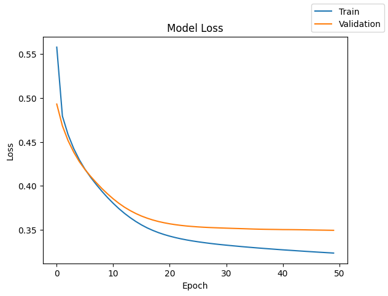

```python
# Plotting train vs validation loss
plot(history_0,'loss')
```

The graph shows the value of the loss function over 50 epochs for both the training and validation sets.

- As expected, both training and validation losses decrease as the number of epochs increases, indicating that the model is learning and the predictions are improving.
- The training loss (blue line) decreases steadily throughout the training process. It starts relatively high around 0.55 and then drops significantly during the first 10 epochs, showing that the model quickly learns key patterns from the training data. After around 30 epochs, the training loss continues to decrease, but at a slower rate, indicating the model is converging.
- The validation loss (orange line) also decreases initially, following a similar trend to the training loss. The validation loss plateaus at a higher value than train, stabilizing after around 20 epochs, which suggests that the model has learned the general patterns in the data without overfitting
- The training loss continues to decrease and is a little lower than the validation loss. Since the validation loss doesn't increase significantly, there is no sign of overfitting and since the loss isn't too far off from the training, it generalizes fairly well.

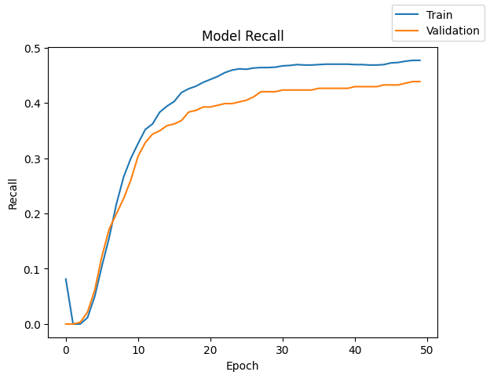

```python
# Plotting train vs validation recall
plot(history_0,'recall')
```

The graph shows the value of the recall metric over 50 epochs for both the training and validation sets.

- Both training and validation recall increase sharply within the first 10 epochs indicating a lot of learning early on.
- Recall on the training set continues to increase steadily, reaching about 0.5 at the end of the training.
- Recall on the validation set also increases steadily and starts the plateau with only marginal improvements after 20 epochs but don't reach the same recall as training.
- The gap in the recall between the two sets is not alarming since they are close. However, given that the recall we reach is only around 0.5, that means we inaccurately classify 50% of the customers who will churn. Hence we do need to optimize the neural networks in different ways to achieve a better result.

This serves as a good base model.

```python
#Predicting the results using 0.5 as a threshold.
# Predict values using the model
y_train_pred = model_0.predict(X_train)
y_val_pred = model_0.predict(X_val)

# Convert predicted value into class 1 or 0. 1 if prob > 0.5 else 0
y_train_pred = (y_train_pred > 0.5)
y_val_pred = (y_val_pred > 0.5)

# Calculate recall for training and validation sets
train_recall = recall_score(y_train, y_train_pred)
val_recall = recall_score(y_val, y_val_pred)

# Print recall scores
print(f"Training Recall: {train_recall:.4f}")
print(f"Validation Recall: {val_recall:.4f}")
```

```
200/200 ━━━━━━━━━━━━━━━━━━━━ 0s 1ms/step
50/50 ━━━━━━━━━━━━━━━━━━━━ 0s 1ms/step
Training Recall: 0.4716
Validation Recall: 0.4387
```

```python
train_metric_df.loc[model_name] = recall_score(y_train, y_train_pred)
valid_metric_df.loc[model_name] = recall_score(y_val, y_val_pred)
```

```python
#classification report
cr = classification_report(y_train, y_train_pred)
print(cr)
```

```
              precision    recall  f1-score   support

           0       0.88      0.97      0.92      5096
           1       0.80      0.47      0.59      1304

    accuracy                           0.87      6400
   macro avg       0.84      0.72      0.76      6400
weighted avg       0.86      0.87      0.85      6400
```

```python
#classification report
cr=classification_report(y_val, y_val_pred)
print(cr)
```

```
              precision    recall  f1-score   support

           0       0.87      0.96      0.91      1274
           1       0.75      0.44      0.55       326

    accuracy                           0.86      1600
   macro avg       0.81      0.70      0.73      1600
weighted avg       0.85      0.86      0.84      1600
```

From the two classification reports, we can observe the following:

- In the training set, we get an accuracy of 0.87 but only a 0.47 recall, with a higher recall for the non churn clients.
- In the validation set, there is an identical pattern of high accuracy and precision but lower recall especially for the churn clients.
- The differences in the metrics between Class 0 and 1 could be due to imbalance in the classes in the Exited variable.

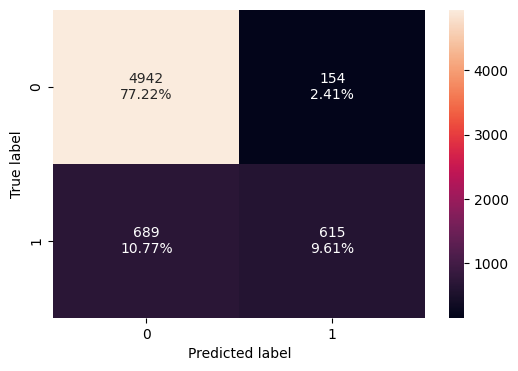

```python
make_confusion_matrix(y_train, y_train_pred)
```

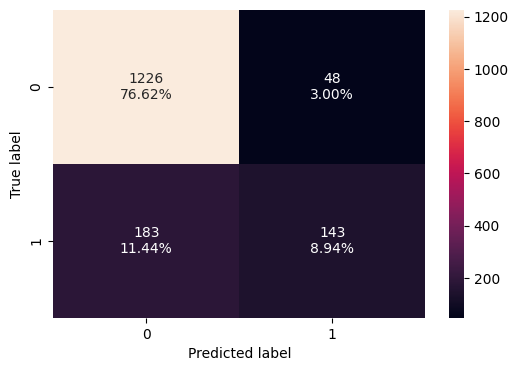

```python
make_confusion_matrix(y_val, y_val_pred)
```

- The neural network with SGD optimizer did nor overfit not underfit, and learnt well and converged within the first 10-20 epochs.
- However, the model doesn't have a satisfactory recall score, especially in the class of customers that churned which is what matters to us the most.
- The model could benefit from optimization like changing the optimizer, trying different sampling techniques or adding layers of Dropout.

## Model Performance Improvement

### Neural Network with Adam Optimizer

```python
backend.clear_session()
np.random.seed(1)
random.seed(1)
tf.random.set_seed(1)

model_name = "NN with Adam"
```

```python
#Create an initial neural netwrok instance
model_1 = Sequential()

# Adding the input layer with 128 neurons and relu as activation function
model_1.add(Dense(64, activation='relu', input_dim = X_train.shape[1]))

# Adding a hidden layer with 64 neurons and relu as activation function
model_1.add(Dense(32, activation='relu'))

# Output layer with 1 neuron for binary classification
model_1.add(Dense(1, activation = 'sigmoid'))
```

```python
model_1.summary()
```

```
Model: "sequential"
```

```
┏━━━━━━━━━━━━━━━━━━━━━━━━━━━━━━━━━━━━━━┳━━━━━━━━━━━━━━━━━━━━━━━━━━━━━┳━━━━━━━━━━━━━━━━━┓
┃ Layer (type)                         ┃ Output Shape                ┃         Param # ┃
┡━━━━━━━━━━━━━━━━━━━━━━━━━━━━━━━━━━━━━━╇━━━━━━━━━━━━━━━━━━━━━━━━━━━━━╇━━━━━━━━━━━━━━━━━┩
│ dense (Dense)                        │ (None, 64)                  │             768 │
├──────────────────────────────────────┼─────────────────────────────┼─────────────────┤
│ dense_1 (Dense)                      │ (None, 32)                  │           2,080 │
├──────────────────────────────────────┼─────────────────────────────┼─────────────────┤
│ dense_2 (Dense)                      │ (None, 1)                   │              33 │
└──────────────────────────────────────┴─────────────────────────────┴─────────────────┘
```

```
 Total params: 2,881 (11.25 KB)
```

```
 Trainable params: 2,881 (11.25 KB)
```

```
 Non-trainable params: 0 (0.00 B)
```

```python
# Create an Adam Optimizer and compile the model
adam_optimizer = keras.optimizers.Adam()
model_1.compile(loss='binary_crossentropy', optimizer=adam_optimizer, metrics=[metric])
```

```python
start = time.time()
history_1 = model_1.fit(X_train, y_train, validation_data=(X_val,y_val) , batch_size=32, epochs=50)
end=time.time()
```

```
200/200 ━━━━━━━━━━━━━━━━━━━━ 2s 3ms/step - loss: 0.5341 - recall: 0.2155 - val_loss: 0.4101 - val_recall: 0.1564
200/200 ━━━━━━━━━━━━━━━━━━━━ 0s 2ms/step - loss: 0.3867 - recall: 0.2548 - val_loss: 0.3733 - val_recall: 0.3037
200/200 ━━━━━━━━━━━━━━━━━━━━ 1s 2ms/step - loss: 0.3497 - recall: 0.3849 - val_loss: 0.3617 - val_recall: 0.3497
200/200 ━━━━━━━━━━━━━━━━━━━━ 1s 2ms/step - loss: 0.3374 - recall: 0.4256 - val_loss: 0.3583 - val_recall: 0.3650
200/200 ━━━━━━━━━━━━━━━━━━━━ 1s 2ms/step - loss: 0.3321 - recall: 0.4424 - val_loss: 0.3565 - val_recall: 0.3650
200/200 ━━━━━━━━━━━━━━━━━━━━ 1s 2ms/step - loss: 0.3285 - recall: 0.4466 - val_loss: 0.3556 - val_recall: 0.3712
200/200 ━━━━━━━━━━━━━━━━━━━━ 1s 2ms/step - loss: 0.3256 - recall: 0.4560 - val_loss: 0.3549 - val_recall: 0.3773
200/200 ━━━━━━━━━━━━━━━━━━━━ 1s 2ms/step - loss: 0.3230 - recall: 0.4655 - val_loss: 0.3540 - val_recall: 0.3834
200/200 ━━━━━━━━━━━━━━━━━━━━ 1s 2ms/step - loss: 0.3208 - recall: 0.4705 - val_loss: 0.3538 - val_recall: 0.3988
200/200 ━━━━━━━━━━━━━━━━━━━━ 1s 2ms/step - loss: 0.3189 - recall: 0.4754 - val_loss: 0.3536 - val_recall: 0.4049
200/200 ━━━━━━━━━━━━━━━━━━━━ 1s 2ms/step - loss: 0.3174 - recall: 0.4748 - val_loss: 0.3538 - val_recall: 0.4141
200/200 ━━━━━━━━━━━━━━━━━━━━ 1s 2ms/step - loss: 0.3158 - recall: 0.4761 - val_loss: 0.3539 - val_recall: 0.4233
200/200 ━━━━━━━━━━━━━━━━━━━━ 1s 2ms/step - loss: 0.3143 - recall: 0.4805 - val_loss: 0.3541 - val_recall: 0.4233
200/200 ━━━━━━━━━━━━━━━━━━━━ 1s 4ms/step - loss: 0.3128 - recall: 0.4820 - val_loss: 0.3545 - val_recall: 0.4264
200/200 ━━━━━━━━━━━━━━━━━━━━ 1s 4ms/step - loss: 0.3114 - recall: 0.4828 - val_loss: 0.3551 - val_recall: 0.4264
200/200 ━━━━━━━━━━━━━━━━━━━━ 1s 4ms/step - loss: 0.3100 - recall: 0.4846 - val_loss: 0.3556 - val_recall: 0.4264
200/200 ━━━━━━━━━━━━━━━━━━━━ 1s 3ms/step - loss: 0.3088 - recall: 0.4884 - val_loss: 0.3557 - val_recall: 0.4294
200/200 ━━━━━━━━━━━━━━━━━━━━ 1s 2ms/step - loss: 0.3075 - recall: 0.4906 - val_loss: 0.3563 - val_recall: 0.4294
200/200 ━━━━━━━━━━━━━━━━━━━━ 0s 2ms/step - loss: 0.3064 - recall: 0.4913 - val_loss: 0.3566 - val_recall: 0.4325
200/200 ━━━━━━━━━━━━━━━━━━━━ 0s 2ms/step - loss: 0.3054 - recall: 0.4948 - val_loss: 0.3574 - val_recall: 0.4325
200/200 ━━━━━━━━━━━━━━━━━━━━ 1s 2ms/step - loss: 0.3043 - recall: 0.5014 - val_loss: 0.3578 - val_recall: 0.4356
200/200 ━━━━━━━━━━━━━━━━━━━━ 1s 2ms/step - loss: 0.3033 - recall: 0.5043 - val_loss: 0.3585 - val_recall: 0.4387
200/200 ━━━━━━━━━━━━━━━━━━━━ 0s 2ms/step - loss: 0.3021 - recall: 0.5052 - val_loss: 0.3594 - val_recall: 0.4387
200/200 ━━━━━━━━━━━━━━━━━━━━ 1s 2ms/step - loss: 0.3011 - recall: 0.5065 - val_loss: 0.3601 - val_recall: 0.4387
200/200 ━━━━━━━━━━━━━━━━━━━━ 1s 2ms/step - loss: 0.3000 - recall: 0.5017 - val_loss: 0.3608 - val_recall: 0.4356
200/200 ━━━━━━━━━━━━━━━━━━━━ 0s 2ms/step - loss: 0.2989 - recall: 0.5075 - val_loss: 0.3616 - val_recall: 0.4325
200/200 ━━━━━━━━━━━━━━━━━━━━ 1s 2ms/step - loss: 0.2979 - recall: 0.5052 - val_loss: 0.3624 - val_recall: 0.4325
200/200 ━━━━━━━━━━━━━━━━━━━━ 1s 2ms/step - loss: 0.2968 - recall: 0.5085 - val_loss: 0.3635 - val_recall: 0.4325
200/200 ━━━━━━━━━━━━━━━━━━━━ 1s 2ms/step - loss: 0.2958 - recall: 0.5100 - val_loss: 0.3643 - val_recall: 0.4294
200/200 ━━━━━━━━━━━━━━━━━━━━ 1s 2ms/step - loss: 0.2947 - recall: 0.5113 - val_loss: 0.3651 - val_recall: 0.4294
200/200 ━━━━━━━━━━━━━━━━━━━━ 1s 2ms/step - loss: 0.2937 - recall: 0.5152 - val_loss: 0.3660 - val_recall: 0.4264
200/200 ━━━━━━━━━━━━━━━━━━━━ 1s 2ms/step - loss: 0.2927 - recall: 0.5158 - val_loss: 0.3664 - val_recall: 0.4264
200/200 ━━━━━━━━━━━━━━━━━━━━ 1s 2ms/step - loss: 0.2917 - recall: 0.5190 - val_loss: 0.3673 - val_recall: 0.4264
200/200 ━━━━━━━━━━━━━━━━━━━━ 1s 2ms/step - loss: 0.2909 - recall: 0.5232 - val_loss: 0.3683 - val_recall: 0.4264
200/200 ━━━━━━━━━━━━━━━━━━━━ 0s 2ms/step - loss: 0.2897 - recall: 0.5254 - val_loss: 0.3695 - val_recall: 0.4264
200/200 ━━━━━━━━━━━━━━━━━━━━ 1s 3ms/step - loss: 0.2888 - recall: 0.5218 - val_loss: 0.3703 - val_recall: 0.4202
200/200 ━━━━━━━━━━━━━━━━━━━━ 1s 3ms/step - loss: 0.2878 - recall: 0.5244 - val_loss: 0.3712 - val_recall: 0.4202
200/200 ━━━━━━━━━━━━━━━━━━━━ 1s 4ms/step - loss: 0.2869 - recall: 0.5270 - val_loss: 0.3720 - val_recall: 0.4202
200/200 ━━━━━━━━━━━━━━━━━━━━ 1s 4ms/step - loss: 0.2856 - recall: 0.5270 - val_loss: 0.3728 - val_recall: 0.4233
200/200 ━━━━━━━━━━━━━━━━━━━━ 1s 3ms/step - loss: 0.2846 - recall: 0.5286 - val_loss: 0.3738 - val_recall: 0.4264
200/200 ━━━━━━━━━━━━━━━━━━━━ 0s 2ms/step - loss: 0.2835 - recall: 0.5316 - val_loss: 0.3747 - val_recall: 0.4264
200/200 ━━━━━━━━━━━━━━━━━━━━ 1s 2ms/step - loss: 0.2825 - recall: 0.5336 - val_loss: 0.3755 - val_recall: 0.4264
200/200 ━━━━━━━━━━━━━━━━━━━━ 1s 2ms/step - loss: 0.2814 - recall: 0.5362 - val_loss: 0.3763 - val_recall: 0.4294
200/200 ━━━━━━━━━━━━━━━━━━━━ 1s 2ms/step - loss: 0.2804 - recall: 0.5376 - val_loss: 0.3772 - val_recall: 0.4294
200/200 ━━━━━━━━━━━━━━━━━━━━ 1s 2ms/step - loss: 0.2793 - recall: 0.5417 - val_loss: 0.3785 - val_recall: 0.4294
200/200 ━━━━━━━━━━━━━━━━━━━━ 1s 2ms/step - loss: 0.2782 - recall: 0.5443 - val_loss: 0.3793 - val_recall: 0.4325
200/200 ━━━━━━━━━━━━━━━━━━━━ 1s 2ms/step - loss: 0.2771 - recall: 0.5460 - val_loss: 0.3806 - val_recall: 0.4387
200/200 ━━━━━━━━━━━━━━━━━━━━ 1s 2ms/step - loss: 0.2761 - recall: 0.5573 - val_loss: 0.3812 - val_recall: 0.4356
200/200 ━━━━━━━━━━━━━━━━━━━━ 1s 2ms/step - loss: 0.2751 - recall: 0.5583 - val_loss: 0.3818 - val_recall: 0.4356
200/200 ━━━━━━━━━━━━━━━━━━━━ 1s 2ms/step - loss: 0.2741 - recall: 0.5523 - val_loss: 0.3822 - val_recall: 0.4356
```

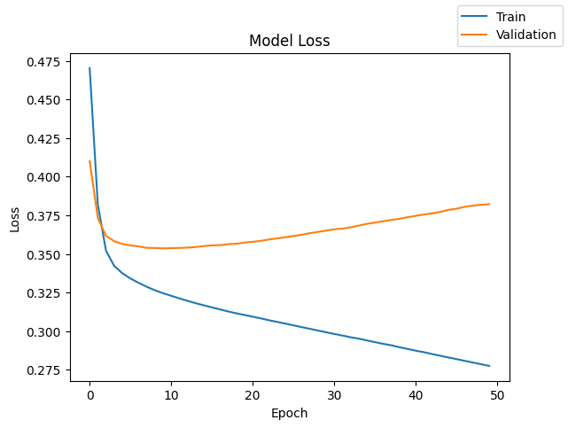

```python
# Plotting train vs validation loss
plot(history_1,'loss')
```

The graph shows the value of the loss function over 50 epochs for both the training and validation sets.

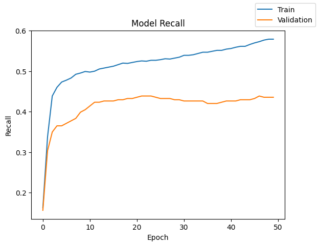

```python
# Plotting train vs validation recall
plot(history_1,'recall')
```

The graph shows the value of the recall metric over 50 epochs for both the training and validation sets.

- Both training and validation recall increase sharply within the first 5 or so epochs, indicating quick learning early on.
- Recall on the training set continues to increase steadily, reaching a higher score of about 0.6 at the end of the training.
- Recall on the validation set already increases steadily and starts to plateau with only marginal improvements after 10 or so epochs but is quite unstable with the increase and decrease in epoch. There are very small fluctuations.
- The gap in the recall between the two sets is significant and may indicate that the model hasn't learned well enough to perform on unseen data. However, given that the recall we reach is still only around 0.6, that means we inaccurately classify 40% of the customers who will churn. Hence, we need to optimize the neural networks in different ways to achieve an even better result.

```python
#Predicting the results using 0.5 as a threshold.
# Predict values using the model
y_train_pred = model_1.predict(X_train)
y_val_pred = model_1.predict(X_val)

# Convert predicted value into class 1 or 0. 1 if prob > 0.5 else 0
y_train_pred = (y_train_pred > 0.5)
y_val_pred = (y_val_pred > 0.5)

# Calculate recall for training and validation sets
train_recall = recall_score(y_train, y_train_pred)
val_recall = recall_score(y_val, y_val_pred)

# Print recall scores
print(f"Training Recall: {train_recall:.4f}")
print(f"Validation Recall: {val_recall:.4f}")
```

```
200/200 ━━━━━━━━━━━━━━━━━━━━ 0s 1ms/step
50/50 ━━━━━━━━━━━━━━━━━━━━ 0s 2ms/step
Training Recall: 0.5199
Validation Recall: 0.4356
```

```python
train_metric_df.loc[model_name] = recall_score(y_train, y_train_pred)
valid_metric_df.loc[model_name] = recall_score(y_val, y_val_pred)
```

```python
#classification report
cr = classification_report(y_train, y_train_pred)
print(cr)
```

```
              precision    recall  f1-score   support

           0       0.89      0.98      0.93      5096
           1       0.87      0.52      0.65      1304

    accuracy                           0.89      6400
   macro avg       0.88      0.75      0.79      6400
weighted avg       0.88      0.89      0.87      6400
```

```python
#classification report
cr=classification_report(y_val, y_val_pred)
print(cr)
```

```
              precision    recall  f1-score   support

           0       0.87      0.95      0.91      1274
           1       0.70      0.44      0.54       326

    accuracy                           0.85      1600
   macro avg       0.79      0.69      0.72      1600
weighted avg       0.83      0.85      0.83      1600
```

From the two classification reports, we can observe the following:

- In the training set, we get an accuracy of 0.89 but only a 0.52 recall, with a higher recall for the non churn clients.
- In the validation set, there is an identical pattern of high accuracy and precision but lower recall especially for the churn clients.
- The difference in recall between the train and validation set is larger than our base model with SGD optimizer which is a potential area of improvement.
- Once again, the differences in the metrics between Class 0 and 1 could be due to imbalance in the classes in the Exited variable.

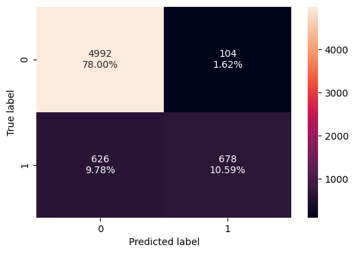

```python
make_confusion_matrix(y_train, y_train_pred)
```

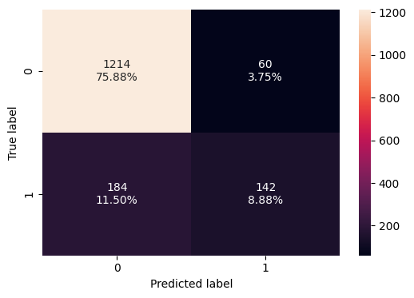

```python
make_confusion_matrix(y_val, y_val_pred)
```

### Neural Network with Adam Optimizer and Dropout

```python
backend.clear_session()
#Fixing the seed for random number generators so that we can ensure we receive the same output everytime
np.random.seed(1)
random.seed(1)
tf.random.set_seed(1)

model_name = "NN with Adam and Dropout"
```

```python
# Set the dropout rate. Trying with both 0.3 and 0.5, this seemed to be the best value to show an example of a neural network with dropout and compare performance
dropout_rate = 0.4
```

```python
#Initializing the neural network
model_2 = Sequential()

# Adding the input layer with 128 neurons and relu as activation function
model_2.add(Dense(64, activation='relu', input_dim = X_train.shape[1]))

# Adding a dropout layer
model_2.add(Dropout(dropout_rate))

# Adding a hidden layer with 32 neurons and relu as activation function
model_2.add(Dense(32, activation='relu'))

# Output layer with 1 neuron for binary classification
model_2.add(Dense(1, activation = 'sigmoid'))
```

```python
model_2.summary()
```

```
Model: "sequential"
```

```
┏━━━━━━━━━━━━━━━━━━━━━━━━━━━━━━━━━━━━━━┳━━━━━━━━━━━━━━━━━━━━━━━━━━━━━┳━━━━━━━━━━━━━━━━━┓
┃ Layer (type)                         ┃ Output Shape                ┃         Param # ┃
┡━━━━━━━━━━━━━━━━━━━━━━━━━━━━━━━━━━━━━━╇━━━━━━━━━━━━━━━━━━━━━━━━━━━━━╇━━━━━━━━━━━━━━━━━┩
│ dense (Dense)                        │ (None, 64)                  │             768 │
├──────────────────────────────────────┼─────────────────────────────┼─────────────────┤
│ dropout (Dropout)                    │ (None, 64)                  │               0 │
├──────────────────────────────────────┼─────────────────────────────┼─────────────────┤
│ dense_1 (Dense)                      │ (None, 32)                  │           2,080 │
├──────────────────────────────────────┼─────────────────────────────┼─────────────────┤
│ dense_2 (Dense)                      │ (None, 1)                   │              33 │
└──────────────────────────────────────┴─────────────────────────────┴─────────────────┘
```

```
 Total params: 2,881 (11.25 KB)
```

```
 Trainable params: 2,881 (11.25 KB)
```

```
 Non-trainable params: 0 (0.00 B)
```

```python
# Create an Adam Optimizer and compile the model
adam_optimizer = keras.optimizers.Adam()
model_2.compile(loss='binary_crossentropy', optimizer=adam_optimizer, metrics=[metric])
```

```python
start = time.time()
history_2 = model_2.fit(X_train, y_train, validation_data=(X_val,y_val) , batch_size=32, epochs=50)
end=time.time()
```

```
200/200 ━━━━━━━━━━━━━━━━━━━━ 5s 9ms/step - loss: 0.5390 - recall: 0.1993 - val_loss: 0.4198 - val_recall: 0.1196
200/200 ━━━━━━━━━━━━━━━━━━━━ 1s 5ms/step - loss: 0.4226 - recall: 0.1788 - val_loss: 0.3907 - val_recall: 0.2546
200/200 ━━━━━━━━━━━━━━━━━━━━ 1s 4ms/step - loss: 0.3947 - recall: 0.2780 - val_loss: 0.3729 - val_recall: 0.3313
200/200 ━━━━━━━━━━━━━━━━━━━━ 1s 4ms/step - loss: 0.3797 - recall: 0.3185 - val_loss: 0.3638 - val_recall: 0.3558
200/200 ━━━━━━━━━━━━━━━━━━━━ 1s 4ms/step - loss: 0.3670 - recall: 0.3557 - val_loss: 0.3591 - val_recall: 0.3742
200/200 ━━━━━━━━━━━━━━━━━━━━ 1s 6ms/step - loss: 0.3586 - recall: 0.3692 - val_loss: 0.3569 - val_recall: 0.3742
200/200 ━━━━━━━━━━━━━━━━━━━━ 2s 9ms/step - loss: 0.3596 - recall: 0.3878 - val_loss: 0.3552 - val_recall: 0.3834
200/200 ━━━━━━━━━━━━━━━━━━━━ 2s 6ms/step - loss: 0.3523 - recall: 0.3810 - val_loss: 0.3524 - val_recall: 0.3804
200/200 ━━━━━━━━━━━━━━━━━━━━ 3s 9ms/step - loss: 0.3510 - recall: 0.3977 - val_loss: 0.3515 - val_recall: 0.3957
200/200 ━━━━━━━━━━━━━━━━━━━━ 1s 5ms/step - loss: 0.3447 - recall: 0.4230 - val_loss: 0.3514 - val_recall: 0.3957
200/200 ━━━━━━━━━━━━━━━━━━━━ 1s 5ms/step - loss: 0.3416 - recall: 0.4160 - val_loss: 0.3485 - val_recall: 0.4233
200/200 ━━━━━━━━━━━━━━━━━━━━ 2s 6ms/step - loss: 0.3448 - recall: 0.4089 - val_loss: 0.3497 - val_recall: 0.4018
200/200 ━━━━━━━━━━━━━━━━━━━━ 2s 5ms/step - loss: 0.3434 - recall: 0.4148 - val_loss: 0.3510 - val_recall: 0.4049
200/200 ━━━━━━━━━━━━━━━━━━━━ 1s 5ms/step - loss: 0.3420 - recall: 0.4203 - val_loss: 0.3504 - val_recall: 0.3988
200/200 ━━━━━━━━━━━━━━━━━━━━ 1s 5ms/step - loss: 0.3401 - recall: 0.4196 - val_loss: 0.3480 - val_recall: 0.4172
200/200 ━━━━━━━━━━━━━━━━━━━━ 2s 6ms/step - loss: 0.3407 - recall: 0.4209 - val_loss: 0.3477 - val_recall: 0.3988
200/200 ━━━━━━━━━━━━━━━━━━━━ 3s 7ms/step - loss: 0.3382 - recall: 0.4237 - val_loss: 0.3480 - val_recall: 0.4110
200/200 ━━━━━━━━━━━━━━━━━━━━ 2s 9ms/step - loss: 0.3299 - recall: 0.4487 - val_loss: 0.3488 - val_recall: 0.3988
200/200 ━━━━━━━━━━━━━━━━━━━━ 2s 7ms/step - loss: 0.3375 - recall: 0.4265 - val_loss: 0.3478 - val_recall: 0.4172
200/200 ━━━━━━━━━━━━━━━━━━━━ 1s 3ms/step - loss: 0.3326 - recall: 0.4402 - val_loss: 0.3467 - val_recall: 0.4049
200/200 ━━━━━━━━━━━━━━━━━━━━ 1s 3ms/step - loss: 0.3348 - recall: 0.4218 - val_loss: 0.3472 - val_recall: 0.4264
200/200 ━━━━━━━━━━━━━━━━━━━━ 1s 2ms/step - loss: 0.3296 - recall: 0.4557 - val_loss: 0.3470 - val_recall: 0.4080
200/200 ━━━━━━━━━━━━━━━━━━━━ 1s 3ms/step - loss: 0.3381 - recall: 0.4382 - val_loss: 0.3461 - val_recall: 0.4202
200/200 ━━━━━━━━━━━━━━━━━━━━ 1s 2ms/step - loss: 0.3255 - recall: 0.4403 - val_loss: 0.3476 - val_recall: 0.4202
200/200 ━━━━━━━━━━━━━━━━━━━━ 1s 2ms/step - loss: 0.3284 - recall: 0.4438 - val_loss: 0.3479 - val_recall: 0.4172
200/200 ━━━━━━━━━━━━━━━━━━━━ 1s 2ms/step - loss: 0.3344 - recall: 0.4350 - val_loss: 0.3483 - val_recall: 0.4172
200/200 ━━━━━━━━━━━━━━━━━━━━ 1s 2ms/step - loss: 0.3240 - recall: 0.4525 - val_loss: 0.3478 - val_recall: 0.4172
200/200 ━━━━━━━━━━━━━━━━━━━━ 1s 3ms/step - loss: 0.3365 - recall: 0.4279 - val_loss: 0.3472 - val_recall: 0.4018
200/200 ━━━━━━━━━━━━━━━━━━━━ 0s 2ms/step - loss: 0.3241 - recall: 0.4668 - val_loss: 0.3472 - val_recall: 0.4264
200/200 ━━━━━━━━━━━━━━━━━━━━ 1s 2ms/step - loss: 0.3279 - recall: 0.4539 - val_loss: 0.3460 - val_recall: 0.4172
200/200 ━━━━━━━━━━━━━━━━━━━━ 1s 2ms/step - loss: 0.3282 - recall: 0.4457 - val_loss: 0.3475 - val_recall: 0.3865
200/200 ━━━━━━━━━━━━━━━━━━━━ 1s 2ms/step - loss: 0.3247 - recall: 0.4538 - val_loss: 0.3473 - val_recall: 0.4172
200/200 ━━━━━━━━━━━━━━━━━━━━ 1s 2ms/step - loss: 0.3230 - recall: 0.4780 - val_loss: 0.3468 - val_recall: 0.4264
200/200 ━━━━━━━━━━━━━━━━━━━━ 0s 2ms/step - loss: 0.3245 - recall: 0.4567 - val_loss: 0.3467 - val_recall: 0.4325
200/200 ━━━━━━━━━━━━━━━━━━━━ 1s 5ms/step - loss: 0.3310 - recall: 0.4418 - val_loss: 0.3474 - val_recall: 0.4325
200/200 ━━━━━━━━━━━━━━━━━━━━ 2s 8ms/step - loss: 0.3234 - recall: 0.4673 - val_loss: 0.3485 - val_recall: 0.4294
200/200 ━━━━━━━━━━━━━━━━━━━━ 2s 6ms/step - loss: 0.3232 - recall: 0.4463 - val_loss: 0.3460 - val_recall: 0.4387
200/200 ━━━━━━━━━━━━━━━━━━━━ 2s 3ms/step - loss: 0.3217 - recall: 0.4866 - val_loss: 0.3478 - val_recall: 0.4172
200/200 ━━━━━━━━━━━━━━━━━━━━ 1s 2ms/step - loss: 0.3286 - recall: 0.4472 - val_loss: 0.3476 - val_recall: 0.4141
200/200 ━━━━━━━━━━━━━━━━━━━━ 1s 2ms/step - loss: 0.3293 - recall: 0.4427 - val_loss: 0.3478 - val_recall: 0.4202
200/200 ━━━━━━━━━━━━━━━━━━━━ 1s 2ms/step - loss: 0.3204 - recall: 0.4575 - val_loss: 0.3479 - val_recall: 0.4356
200/200 ━━━━━━━━━━━━━━━━━━━━ 1s 2ms/step - loss: 0.3219 - recall: 0.4479 - val_loss: 0.3478 - val_recall: 0.4479
200/200 ━━━━━━━━━━━━━━━━━━━━ 0s 2ms/step - loss: 0.3225 - recall: 0.4617 - val_loss: 0.3472 - val_recall: 0.4356
200/200 ━━━━━━━━━━━━━━━━━━━━ 1s 2ms/step - loss: 0.3208 - recall: 0.4561 - val_loss: 0.3470 - val_recall: 0.4479
200/200 ━━━━━━━━━━━━━━━━━━━━ 1s 2ms/step - loss: 0.3224 - recall: 0.4702 - val_loss: 0.3492 - val_recall: 0.4479
200/200 ━━━━━━━━━━━━━━━━━━━━ 0s 2ms/step - loss: 0.3238 - recall: 0.4557 - val_loss: 0.3472 - val_recall: 0.4479
200/200 ━━━━━━━━━━━━━━━━━━━━ 1s 2ms/step - loss: 0.3222 - recall: 0.4525 - val_loss: 0.3489 - val_recall: 0.4387
200/200 ━━━━━━━━━━━━━━━━━━━━ 1s 2ms/step - loss: 0.3239 - recall: 0.4543 - val_loss: 0.3482 - val_recall: 0.4448
200/200 ━━━━━━━━━━━━━━━━━━━━ 1s 2ms/step - loss: 0.3219 - recall: 0.4519 - val_loss: 0.3486 - val_recall: 0.4417
200/200 ━━━━━━━━━━━━━━━━━━━━ 1s 2ms/step - loss: 0.3231 - recall: 0.4644 - val_loss: 0.3485 - val_recall: 0.4448
```

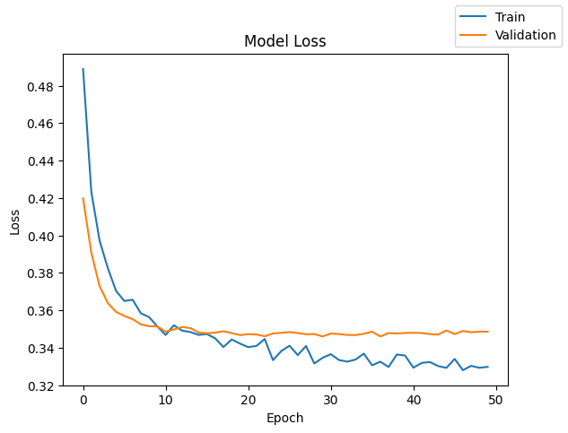

```python
# Plotting train vs validation loss
plot(history_2,'loss')
```

The graph shows the value of the loss function over 50 epochs for both the training and validation sets.

- As expected, both training and validation losses decrease as the number of epochs increases, indicating that the model is learning and the predictions are improving.
- The training loss (blue line) decreases steadily throughout the training process. It starts around around 0.48 and then drops significantly during the first 5 epochs, showing that the model quickly learns key patterns from the training data. The model continues to learn and the loss continues to decrease at a slower rate with visible fluctuations as the number of epochs increases, however still with an overall reduction.
- The validation loss (orange line) also decreases initially sharply, following a similar trend to the training loss. The validation loss seems more stable than training loss and converges very quickly with almost no fluctuation or decrease after 10 or so epochs.
- The gap between the two is minor but exists because of the fluctuations of the training set loss.

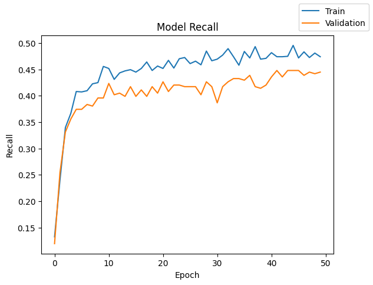

```python
# Plotting train vs validation recall
plot(history_2,'recall')
```

The graph shows the value of the recall metric over 50 epochs for both the training and validation sets.

- Both training and validation recall increase sharply within the first 5 or so epochs indicating rapid learning early on.
- Recall on the training set continues to increase steadily, reaching a score of about 0.45 at the end of the training with many fluctuations and instability after 10 or so epochs.
- Recall on the validation set already increases steadily and then increases marginally with a lot of instability after 10 epochs with many apparent fluctuations.
- The gap in the recall between the two sets is nearly constant within the fluctuations that both display and they are fairly close to each other.
- However, given that the recall we reach is still only around 0.45, we haven't seen any significant improvement in adding a dropout layer to this model and also the instability of the learning is of concern.

```python
#Predicting the results using 0.5 as a threshold.
# Predict values using the model
y_train_pred = model_2.predict(X_train)
y_val_pred = model_2.predict(X_val)

# Convert predicted value into class 1 or 0. 1 if prob > 0.5 else 0
y_train_pred = (y_train_pred > 0.5)
y_val_pred = (y_val_pred > 0.5)

# Calculate recall for training and validation sets
train_recall = recall_score(y_train, y_train_pred)
val_recall = recall_score(y_val, y_val_pred)

# Print recall scores
print(f"Training Recall: {train_recall:.4f}")
print(f"Validation Recall: {val_recall:.4f}")
```

```
200/200 ━━━━━━━━━━━━━━━━━━━━ 0s 1ms/step
50/50 ━━━━━━━━━━━━━━━━━━━━ 0s 1ms/step
Training Recall: 0.4824
Validation Recall: 0.4448
```

```python
train_metric_df.loc[model_name] = recall_score(y_train, y_train_pred)
valid_metric_df.loc[model_name] = recall_score(y_val, y_val_pred)
```

```python
#classification report
cr = classification_report(y_train, y_train_pred)
print(cr)
```

```
              precision    recall  f1-score   support

           0       0.88      0.97      0.92      5096
           1       0.81      0.48      0.60      1304

    accuracy                           0.87      6400
   macro avg       0.85      0.73      0.76      6400
weighted avg       0.87      0.87      0.86      6400
```

```python
#classification report
cr=classification_report(y_val, y_val_pred)
print(cr)
```

```
              precision    recall  f1-score   support

           0       0.87      0.96      0.92      1274
           1       0.76      0.44      0.56       326

    accuracy                           0.86      1600
   macro avg       0.82      0.70      0.74      1600
weighted avg       0.85      0.86      0.84      1600
```

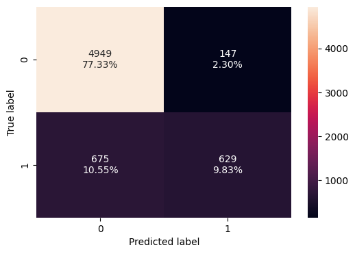

```python
make_confusion_matrix(y_train, y_train_pred)
```

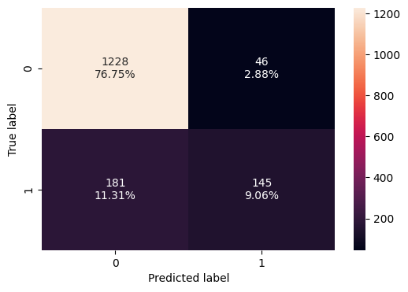

```python
make_confusion_matrix(y_val, y_val_pred)
```

### Neural Network with Balanced Data (by applying SMOTE) and SGD Optimizer

```python
backend.clear_session()
#Fixing the seed for random number generators so that we can ensure we receive the same output everytime
np.random.seed(1)
random.seed(1)
tf.random.set_seed(1)

model_name = "NN with SMOTE and SGD"
```

```python
# Apply SMOTE oversampling to the training data
sm = SMOTE(sampling_strategy=1, k_neighbors=5, random_state=1)
X_train_smote, y_train_smote = sm.fit_resample(X_train, y_train)
```

```python
#Initializing the neural network
model_3 = Sequential()

# Adding the input layer with 128 neurons and relu as activation function
model_3.add(Dense(64, activation='relu', input_dim = X_train_smote.shape[1]))

# Adding a hidden layer with 32 neurons and relu as activation function
model_3.add(Dense(32, activation='relu'))

# Output layer with 1 neuron for binary classification
model_3.add(Dense(1, activation = 'sigmoid'))
```

```python
model_3.summary()
```

```
Model: "sequential"
```

```
┏━━━━━━━━━━━━━━━━━━━━━━━━━━━━━━━━━━━━━━┳━━━━━━━━━━━━━━━━━━━━━━━━━━━━━┳━━━━━━━━━━━━━━━━━┓
┃ Layer (type)                         ┃ Output Shape                ┃         Param # ┃
┡━━━━━━━━━━━━━━━━━━━━━━━━━━━━━━━━━━━━━━╇━━━━━━━━━━━━━━━━━━━━━━━━━━━━━╇━━━━━━━━━━━━━━━━━┩
│ dense (Dense)                        │ (None, 64)                  │             768 │
├──────────────────────────────────────┼─────────────────────────────┼─────────────────┤
│ dense_1 (Dense)                      │ (None, 32)                  │           2,080 │
├──────────────────────────────────────┼─────────────────────────────┼─────────────────┤
│ dense_2 (Dense)                      │ (None, 1)                   │              33 │
└──────────────────────────────────────┴─────────────────────────────┴─────────────────┘
```

```
 Total params: 2,881 (11.25 KB)
```

```
 Trainable params: 2,881 (11.25 KB)
```

```
 Non-trainable params: 0 (0.00 B)
```

```python
# Create an SGD Optimizer and compile the model
optimizer = keras.optimizers.SGD()
model_3.compile(loss='binary_crossentropy', optimizer=optimizer, metrics=[metric])
```

```python
start = time.time()
history_3 = model_3.fit(X_train_smote, y_train_smote, validation_data=(X_val,y_val) , batch_size=32, epochs=50)
end=time.time()
```

```
319/319 ━━━━━━━━━━━━━━━━━━━━ 3s 8ms/step - loss: 0.6796 - recall: 0.6664 - val_loss: 0.6239 - val_recall: 0.6472
319/319 ━━━━━━━━━━━━━━━━━━━━ 1s 4ms/step - loss: 0.6140 - recall: 0.7072 - val_loss: 0.5699 - val_recall: 0.6718
319/319 ━━━━━━━━━━━━━━━━━━━━ 3s 4ms/step - loss: 0.5667 - recall: 0.7297 - val_loss: 0.5320 - val_recall: 0.6994
319/319 ━━━━━━━━━━━━━━━━━━━━ 4s 7ms/step - loss: 0.5346 - recall: 0.7416 - val_loss: 0.5046 - val_recall: 0.7025
319/319 ━━━━━━━━━━━━━━━━━━━━ 2s 7ms/step - loss: 0.5106 - recall: 0.7566 - val_loss: 0.4817 - val_recall: 0.7086
319/319 ━━━━━━━━━━━━━━━━━━━━ 1s 2ms/step - loss: 0.4908 - recall: 0.7684 - val_loss: 0.4631 - val_recall: 0.7301
319/319 ━━━━━━━━━━━━━━━━━━━━ 1s 2ms/step - loss: 0.4748 - recall: 0.7784 - val_loss: 0.4495 - val_recall: 0.7239
319/319 ━━━━━━━━━━━━━━━━━━━━ 1s 2ms/step - loss: 0.4630 - recall: 0.7800 - val_loss: 0.4409 - val_recall: 0.7117
319/319 ━━━━━━━━━━━━━━━━━━━━ 1s 2ms/step - loss: 0.4546 - recall: 0.7800 - val_loss: 0.4349 - val_recall: 0.7117
319/319 ━━━━━━━━━━━━━━━━━━━━ 1s 2ms/step - loss: 0.4485 - recall: 0.7811 - val_loss: 0.4306 - val_recall: 0.7086
319/319 ━━━━━━━━━━━━━━━━━━━━ 1s 2ms/step - loss: 0.4440 - recall: 0.7806 - val_loss: 0.4279 - val_recall: 0.7117
319/319 ━━━━━━━━━━━━━━━━━━━━ 1s 2ms/step - loss: 0.4405 - recall: 0.7853 - val_loss: 0.4258 - val_recall: 0.7178
319/319 ━━━━━━━━━━━━━━━━━━━━ 1s 2ms/step - loss: 0.4377 - recall: 0.7877 - val_loss: 0.4242 - val_recall: 0.7209
319/319 ━━━━━━━━━━━━━━━━━━━━ 1s 2ms/step - loss: 0.4353 - recall: 0.7875 - val_loss: 0.4233 - val_recall: 0.7178
319/319 ━━━━━━━━━━━━━━━━━━━━ 1s 2ms/step - loss: 0.4331 - recall: 0.7897 - val_loss: 0.4225 - val_recall: 0.7209
319/319 ━━━━━━━━━━━━━━━━━━━━ 1s 2ms/step - loss: 0.4311 - recall: 0.7895 - val_loss: 0.4216 - val_recall: 0.7178
319/319 ━━━━━━━━━━━━━━━━━━━━ 1s 2ms/step - loss: 0.4293 - recall: 0.7906 - val_loss: 0.4209 - val_recall: 0.7178
319/319 ━━━━━━━━━━━━━━━━━━━━ 1s 2ms/step - loss: 0.4276 - recall: 0.7913 - val_loss: 0.4203 - val_recall: 0.7178
319/319 ━━━━━━━━━━━━━━━━━━━━ 2s 3ms/step - loss: 0.4261 - recall: 0.7911 - val_loss: 0.4196 - val_recall: 0.7117
319/319 ━━━━━━━━━━━━━━━━━━━━ 1s 3ms/step - loss: 0.4246 - recall: 0.7921 - val_loss: 0.4189 - val_recall: 0.7117
319/319 ━━━━━━━━━━━━━━━━━━━━ 1s 3ms/step - loss: 0.4233 - recall: 0.7925 - val_loss: 0.4183 - val_recall: 0.7117
319/319 ━━━━━━━━━━━━━━━━━━━━ 1s 3ms/step - loss: 0.4220 - recall: 0.7934 - val_loss: 0.4179 - val_recall: 0.7117
319/319 ━━━━━━━━━━━━━━━━━━━━ 1s 2ms/step - loss: 0.4207 - recall: 0.7940 - val_loss: 0.4175 - val_recall: 0.7086
319/319 ━━━━━━━━━━━━━━━━━━━━ 1s 2ms/step - loss: 0.4195 - recall: 0.7925 - val_loss: 0.4173 - val_recall: 0.7086
319/319 ━━━━━━━━━━━━━━━━━━━━ 1s 2ms/step - loss: 0.4184 - recall: 0.7927 - val_loss: 0.4174 - val_recall: 0.7117
319/319 ━━━━━━━━━━━━━━━━━━━━ 1s 2ms/step - loss: 0.4173 - recall: 0.7937 - val_loss: 0.4170 - val_recall: 0.7117
319/319 ━━━━━━━━━━━━━━━━━━━━ 1s 2ms/step - loss: 0.4163 - recall: 0.7945 - val_loss: 0.4169 - val_recall: 0.7117
319/319 ━━━━━━━━━━━━━━━━━━━━ 1s 2ms/step - loss: 0.4152 - recall: 0.7962 - val_loss: 0.4169 - val_recall: 0.7117
319/319 ━━━━━━━━━━━━━━━━━━━━ 1s 2ms/step - loss: 0.4142 - recall: 0.7977 - val_loss: 0.4167 - val_recall: 0.7117
319/319 ━━━━━━━━━━━━━━━━━━━━ 1s 2ms/step - loss: 0.4132 - recall: 0.7993 - val_loss: 0.4166 - val_recall: 0.7086
319/319 ━━━━━━━━━━━━━━━━━━━━ 1s 2ms/step - loss: 0.4122 - recall: 0.8004 - val_loss: 0.4164 - val_recall: 0.7117
319/319 ━━━━━━━━━━━━━━━━━━━━ 1s 2ms/step - loss: 0.4112 - recall: 0.8033 - val_loss: 0.4161 - val_recall: 0.7117
319/319 ━━━━━━━━━━━━━━━━━━━━ 1s 2ms/step - loss: 0.4103 - recall: 0.8048 - val_loss: 0.4159 - val_recall: 0.7117
319/319 ━━━━━━━━━━━━━━━━━━━━ 1s 2ms/step - loss: 0.4093 - recall: 0.8050 - val_loss: 0.4158 - val_recall: 0.7117
319/319 ━━━━━━━━━━━━━━━━━━━━ 1s 2ms/step - loss: 0.4084 - recall: 0.8053 - val_loss: 0.4157 - val_recall: 0.7117
319/319 ━━━━━━━━━━━━━━━━━━━━ 1s 2ms/step - loss: 0.4075 - recall: 0.8058 - val_loss: 0.4157 - val_recall: 0.7117
319/319 ━━━━━━━━━━━━━━━━━━━━ 1s 2ms/step - loss: 0.4066 - recall: 0.8062 - val_loss: 0.4154 - val_recall: 0.7117
319/319 ━━━━━━━━━━━━━━━━━━━━ 1s 3ms/step - loss: 0.4058 - recall: 0.8055 - val_loss: 0.4153 - val_recall: 0.7086
319/319 ━━━━━━━━━━━━━━━━━━━━ 1s 3ms/step - loss: 0.4049 - recall: 0.8070 - val_loss: 0.4153 - val_recall: 0.7086
319/319 ━━━━━━━━━━━━━━━━━━━━ 1s 3ms/step - loss: 0.4041 - recall: 0.8069 - val_loss: 0.4152 - val_recall: 0.7086
319/319 ━━━━━━━━━━━━━━━━━━━━ 1s 3ms/step - loss: 0.4032 - recall: 0.8084 - val_loss: 0.4152 - val_recall: 0.7055
319/319 ━━━━━━━━━━━━━━━━━━━━ 1s 2ms/step - loss: 0.4024 - recall: 0.8095 - val_loss: 0.4150 - val_recall: 0.7055
319/319 ━━━━━━━━━━━━━━━━━━━━ 1s 2ms/step - loss: 0.4015 - recall: 0.8095 - val_loss: 0.4152 - val_recall: 0.7086
319/319 ━━━━━━━━━━━━━━━━━━━━ 1s 2ms/step - loss: 0.4007 - recall: 0.8114 - val_loss: 0.4152 - val_recall: 0.7025
319/319 ━━━━━━━━━━━━━━━━━━━━ 1s 2ms/step - loss: 0.3999 - recall: 0.8119 - val_loss: 0.4153 - val_recall: 0.7055
319/319 ━━━━━━━━━━━━━━━━━━━━ 1s 2ms/step - loss: 0.3990 - recall: 0.8125 - val_loss: 0.4153 - val_recall: 0.7025
319/319 ━━━━━━━━━━━━━━━━━━━━ 1s 2ms/step - loss: 0.3982 - recall: 0.8132 - val_loss: 0.4152 - val_recall: 0.6994
319/319 ━━━━━━━━━━━━━━━━━━━━ 1s 2ms/step - loss: 0.3973 - recall: 0.8134 - val_loss: 0.4154 - val_recall: 0.7025
319/319 ━━━━━━━━━━━━━━━━━━━━ 1s 2ms/step - loss: 0.3965 - recall: 0.8139 - val_loss: 0.4153 - val_recall: 0.6994
319/319 ━━━━━━━━━━━━━━━━━━━━ 1s 2ms/step - loss: 0.3956 - recall: 0.8146 - val_loss: 0.4155 - val_recall: 0.6963
```

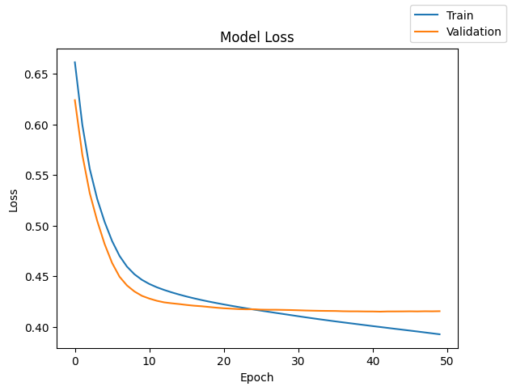

```python
# Plotting train vs validation loss
plot(history_3,'loss')
```

- As expected, both training and validation losses decrease as the number of epochs increases, indicating that the model is learning and the predictions are improving.
- The training loss (blue line) decreases steadily throughout the training process. It starts around around 0.65 and then drops significantly during the first 10 epochs, showing that the model quickly learns key patterns from the training data. The model continues to learn and converges at a steady rate while the loss function continues to decrease but very slowly.
- The validation loss (orange line) also decreases initially sharply, following a similar trend to the training loss. The validation loss stabilizes and plateaus after 10 epochs and the loss is constant, almost a straight line.
- The gap between the two is small, and move together which shows that the model is able to generalize well and reduce loss even on unseen data.

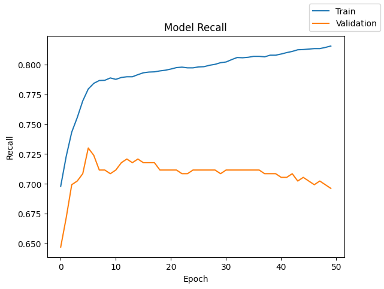

```python
# Plotting train vs validation recall
plot(history_3,'recall')
```

```python
#Predicting the results using 0.5 as a threshold.
# Predict values using the model
y_train_pred = model_3.predict(X_train)
y_val_pred = model_3.predict(X_val)

# Convert predicted value into class 1 or 0. 1 if prob > 0.5 else 0
y_train_pred = (y_train_pred > 0.5)
y_val_pred = (y_val_pred > 0.5)

# Calculate recall for training and validation sets
train_recall = recall_score(y_train, y_train_pred)
val_recall = recall_score(y_val, y_val_pred)

# Print recall scores
print(f"Training Recall: {train_recall:.4f}")
print(f"Validation Recall: {val_recall:.4f}")
```

```
200/200 ━━━━━━━━━━━━━━━━━━━━ 1s 2ms/step
50/50 ━━━━━━━━━━━━━━━━━━━━ 0s 2ms/step
Training Recall: 0.7462
Validation Recall: 0.6963
```

```python
train_metric_df.loc[model_name] = recall_score(y_train, y_train_pred)
valid_metric_df.loc[model_name] = recall_score(y_val, y_val_pred)
```

```python
#classification report
cr = classification_report(y_train, y_train_pred)
print(cr)
```

```
              precision    recall  f1-score   support

           0       0.93      0.86      0.89      5096
           1       0.57      0.75      0.65      1304

    accuracy                           0.83      6400
   macro avg       0.75      0.80      0.77      6400
weighted avg       0.86      0.83      0.84      6400
```

```python
#classification report
cr=classification_report(y_val, y_val_pred)
print(cr)
```

```
              precision    recall  f1-score   support

           0       0.92      0.85      0.88      1274
           1       0.54      0.70      0.61       326

    accuracy                           0.82      1600
   macro avg       0.73      0.77      0.75      1600
weighted avg       0.84      0.82      0.83      1600
```

From the two classification reports, we can observe the following:

- In the training set, we get an accuracy of 0.83 and a 0.80 average recall, with a slightly higher recall for the non churn customers.
- In the validation set, there is an identical pattern of high accuracy and precision but lower recall especially for the churn customers.
- The difference in recall between the train and validation set is small but the difference in value of the recall for Class 0 vs Class 1 is much lower than before, meaning we have managed to eliminate the imbalance in the data.

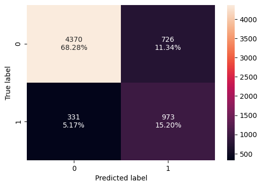

```python
make_confusion_matrix(y_train, y_train_pred)
```

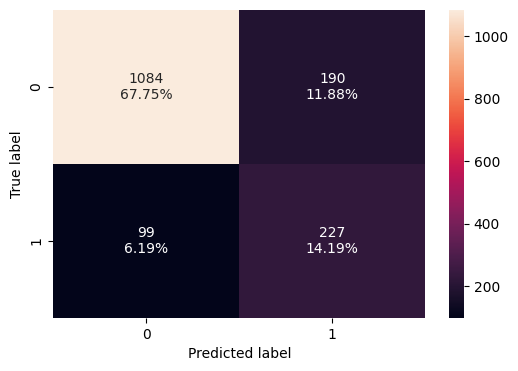

```python
make_confusion_matrix(y_val, y_val_pred)
```

### Neural Network with Balanced Data (by applying SMOTE) and Adam Optimizer

```python
backend.clear_session()
#Fixing the seed for random number generators so that we can ensure we receive the same output everytime
np.random.seed(1)
random.seed(1)
tf.random.set_seed(1)

model_name = "NN with SMOTE and Adam"
```

```python
#Initializing the neural network
model_4 = Sequential()

# Adding the input layer with 128 neurons and relu as activation function
model_4.add(Dense(64, activation='relu', input_dim = X_train_smote.shape[1]))

# Adding a hidden layer with 32 neurons and relu as activation function
model_4.add(Dense(32, activation='relu'))

# Output layer with 1 neuron for binary classification
model_4.add(Dense(1, activation = 'sigmoid'))
```

```python
model_4.summary()
```

```
Model: "sequential"
```

```
┏━━━━━━━━━━━━━━━━━━━━━━━━━━━━━━━━━━━━━━┳━━━━━━━━━━━━━━━━━━━━━━━━━━━━━┳━━━━━━━━━━━━━━━━━┓
┃ Layer (type)                         ┃ Output Shape                ┃         Param # ┃
┡━━━━━━━━━━━━━━━━━━━━━━━━━━━━━━━━━━━━━━╇━━━━━━━━━━━━━━━━━━━━━━━━━━━━━╇━━━━━━━━━━━━━━━━━┩
│ dense (Dense)                        │ (None, 64)                  │             768 │
├──────────────────────────────────────┼─────────────────────────────┼─────────────────┤
│ dense_1 (Dense)                      │ (None, 32)                  │           2,080 │
├──────────────────────────────────────┼─────────────────────────────┼─────────────────┤
│ dense_2 (Dense)                      │ (None, 1)                   │              33 │
└──────────────────────────────────────┴─────────────────────────────┴─────────────────┘
```

```
 Total params: 2,881 (11.25 KB)
```

```
 Trainable params: 2,881 (11.25 KB)
```

```
 Non-trainable params: 0 (0.00 B)
```

```python
adam_optimizer = keras.optimizers.Adam()
model_4.compile(loss='binary_crossentropy', optimizer=adam_optimizer, metrics=[metric])
```

```python
start = time.time()
history_4 = model_4.fit(X_train_smote, y_train_smote, validation_data=(X_val,y_val) , batch_size=32, epochs=50)
end=time.time()
```

```
319/319 ━━━━━━━━━━━━━━━━━━━━ 6s 6ms/step - loss: 0.5909 - recall: 0.7537 - val_loss: 0.4347 - val_recall: 0.7055
319/319 ━━━━━━━━━━━━━━━━━━━━ 1s 4ms/step - loss: 0.4506 - recall: 0.7902 - val_loss: 0.4181 - val_recall: 0.7086
319/319 ━━━━━━━━━━━━━━━━━━━━ 3s 4ms/step - loss: 0.4323 - recall: 0.7963 - val_loss: 0.4161 - val_recall: 0.7147
319/319 ━━━━━━━━━━━━━━━━━━━━ 2s 5ms/step - loss: 0.4230 - recall: 0.8033 - val_loss: 0.4138 - val_recall: 0.7025
319/319 ━━━━━━━━━━━━━━━━━━━━ 2s 4ms/step - loss: 0.4159 - recall: 0.8074 - val_loss: 0.4147 - val_recall: 0.7055
319/319 ━━━━━━━━━━━━━━━━━━━━ 2s 7ms/step - loss: 0.4099 - recall: 0.8070 - val_loss: 0.4161 - val_recall: 0.6994
319/319 ━━━━━━━━━━━━━━━━━━━━ 1s 4ms/step - loss: 0.4043 - recall: 0.8132 - val_loss: 0.4179 - val_recall: 0.6994
319/319 ━━━━━━━━━━━━━━━━━━━━ 1s 4ms/step - loss: 0.3993 - recall: 0.8172 - val_loss: 0.4203 - val_recall: 0.6933
319/319 ━━━━━━━━━━━━━━━━━━━━ 1s 3ms/step - loss: 0.3943 - recall: 0.8215 - val_loss: 0.4226 - val_recall: 0.6871
319/319 ━━━━━━━━━━━━━━━━━━━━ 1s 2ms/step - loss: 0.3894 - recall: 0.8259 - val_loss: 0.4253 - val_recall: 0.6871
319/319 ━━━━━━━━━━━━━━━━━━━━ 1s 2ms/step - loss: 0.3849 - recall: 0.8289 - val_loss: 0.4275 - val_recall: 0.6871
319/319 ━━━━━━━━━━━━━━━━━━━━ 1s 2ms/step - loss: 0.3805 - recall: 0.8331 - val_loss: 0.4307 - val_recall: 0.6810
319/319 ━━━━━━━━━━━━━━━━━━━━ 1s 2ms/step - loss: 0.3762 - recall: 0.8361 - val_loss: 0.4338 - val_recall: 0.6840
319/319 ━━━━━━━━━━━━━━━━━━━━ 1s 2ms/step - loss: 0.3718 - recall: 0.8358 - val_loss: 0.4365 - val_recall: 0.6810
319/319 ━━━━━━━━━━━━━━━━━━━━ 1s 2ms/step - loss: 0.3676 - recall: 0.8376 - val_loss: 0.4394 - val_recall: 0.6871
319/319 ━━━━━━━━━━━━━━━━━━━━ 1s 2ms/step - loss: 0.3633 - recall: 0.8407 - val_loss: 0.4419 - val_recall: 0.6902
319/319 ━━━━━━━━━━━━━━━━━━━━ 1s 2ms/step - loss: 0.3594 - recall: 0.8437 - val_loss: 0.4446 - val_recall: 0.6933
319/319 ━━━━━━━━━━━━━━━━━━━━ 1s 2ms/step - loss: 0.3558 - recall: 0.8453 - val_loss: 0.4474 - val_recall: 0.6902
319/319 ━━━━━━━━━━━━━━━━━━━━ 2s 3ms/step - loss: 0.3520 - recall: 0.8500 - val_loss: 0.4501 - val_recall: 0.6933
319/319 ━━━━━━━━━━━━━━━━━━━━ 1s 3ms/step - loss: 0.3484 - recall: 0.8532 - val_loss: 0.4522 - val_recall: 0.6933
319/319 ━━━━━━━━━━━━━━━━━━━━ 1s 4ms/step - loss: 0.3448 - recall: 0.8574 - val_loss: 0.4534 - val_recall: 0.6933
319/319 ━━━━━━━━━━━━━━━━━━━━ 1s 3ms/step - loss: 0.3413 - recall: 0.8580 - val_loss: 0.4558 - val_recall: 0.6933
319/319 ━━━━━━━━━━━━━━━━━━━━ 1s 2ms/step - loss: 0.3379 - recall: 0.8608 - val_loss: 0.4578 - val_recall: 0.6963
319/319 ━━━━━━━━━━━━━━━━━━━━ 1s 2ms/step - loss: 0.3348 - recall: 0.8619 - val_loss: 0.4605 - val_recall: 0.6963
319/319 ━━━━━━━━━━━━━━━━━━━━ 1s 2ms/step - loss: 0.3318 - recall: 0.8610 - val_loss: 0.4619 - val_recall: 0.6963
319/319 ━━━━━━━━━━━━━━━━━━━━ 1s 2ms/step - loss: 0.3288 - recall: 0.8658 - val_loss: 0.4645 - val_recall: 0.7025
319/319 ━━━━━━━━━━━━━━━━━━━━ 1s 2ms/step - loss: 0.3259 - recall: 0.8664 - val_loss: 0.4663 - val_recall: 0.7055
319/319 ━━━━━━━━━━━━━━━━━━━━ 1s 2ms/step - loss: 0.3230 - recall: 0.8666 - val_loss: 0.4686 - val_recall: 0.6994
319/319 ━━━━━━━━━━━━━━━━━━━━ 1s 2ms/step - loss: 0.3205 - recall: 0.8667 - val_loss: 0.4704 - val_recall: 0.7055
319/319 ━━━━━━━━━━━━━━━━━━━━ 1s 2ms/step - loss: 0.3180 - recall: 0.8702 - val_loss: 0.4719 - val_recall: 0.7055
319/319 ━━━━━━━━━━━━━━━━━━━━ 2s 3ms/step - loss: 0.3154 - recall: 0.8733 - val_loss: 0.4729 - val_recall: 0.6994
319/319 ━━━━━━━━━━━━━━━━━━━━ 1s 3ms/step - loss: 0.3128 - recall: 0.8764 - val_loss: 0.4750 - val_recall: 0.6963
319/319 ━━━━━━━━━━━━━━━━━━━━ 1s 3ms/step - loss: 0.3105 - recall: 0.8774 - val_loss: 0.4771 - val_recall: 0.6963
319/319 ━━━━━━━━━━━━━━━━━━━━ 1s 3ms/step - loss: 0.3082 - recall: 0.8777 - val_loss: 0.4790 - val_recall: 0.6933
319/319 ━━━━━━━━━━━━━━━━━━━━ 1s 2ms/step - loss: 0.3060 - recall: 0.8819 - val_loss: 0.4828 - val_recall: 0.6963
319/319 ━━━━━━━━━━━━━━━━━━━━ 1s 2ms/step - loss: 0.3040 - recall: 0.8820 - val_loss: 0.4855 - val_recall: 0.6994
319/319 ━━━━━━━━━━━━━━━━━━━━ 1s 2ms/step - loss: 0.3020 - recall: 0.8846 - val_loss: 0.4888 - val_recall: 0.6963
319/319 ━━━━━━━━━━━━━━━━━━━━ 1s 2ms/step - loss: 0.3001 - recall: 0.8837 - val_loss: 0.4920 - val_recall: 0.6933
319/319 ━━━━━━━━━━━━━━━━━━━━ 1s 2ms/step - loss: 0.2981 - recall: 0.8859 - val_loss: 0.4942 - val_recall: 0.6933
319/319 ━━━━━━━━━━━━━━━━━━━━ 1s 2ms/step - loss: 0.2961 - recall: 0.8876 - val_loss: 0.4976 - val_recall: 0.6902
319/319 ━━━━━━━━━━━━━━━━━━━━ 1s 2ms/step - loss: 0.2943 - recall: 0.8887 - val_loss: 0.5004 - val_recall: 0.6840
319/319 ━━━━━━━━━━━━━━━━━━━━ 1s 2ms/step - loss: 0.2925 - recall: 0.8897 - val_loss: 0.5048 - val_recall: 0.6840
319/319 ━━━━━━━━━━━━━━━━━━━━ 1s 2ms/step - loss: 0.2907 - recall: 0.8917 - val_loss: 0.5058 - val_recall: 0.6840
319/319 ━━━━━━━━━━━━━━━━━━━━ 1s 2ms/step - loss: 0.2888 - recall: 0.8947 - val_loss: 0.5087 - val_recall: 0.6871
319/319 ━━━━━━━━━━━━━━━━━━━━ 1s 2ms/step - loss: 0.2871 - recall: 0.8965 - val_loss: 0.5117 - val_recall: 0.6840
319/319 ━━━━━━━━━━━━━━━━━━━━ 1s 3ms/step - loss: 0.2852 - recall: 0.8980 - val_loss: 0.5149 - val_recall: 0.6810
319/319 ━━━━━━━━━━━━━━━━━━━━ 1s 3ms/step - loss: 0.2834 - recall: 0.8978 - val_loss: 0.5167 - val_recall: 0.6810
319/319 ━━━━━━━━━━━━━━━━━━━━ 1s 4ms/step - loss: 0.2818 - recall: 0.8998 - val_loss: 0.5185 - val_recall: 0.6779
319/319 ━━━━━━━━━━━━━━━━━━━━ 1s 4ms/step - loss: 0.2804 - recall: 0.8999 - val_loss: 0.5204 - val_recall: 0.6810
319/319 ━━━━━━━━━━━━━━━━━━━━ 1s 2ms/step - loss: 0.2787 - recall: 0.9006 - val_loss: 0.5227 - val_recall: 0.6779
```

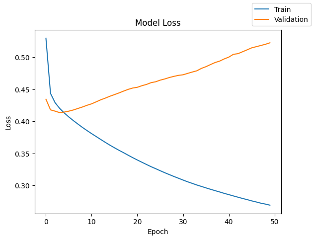

```python
# Plotting train vs validation loss
plot(history_4,'loss')
```

- The training loss (blue line) decreases consistently throughout the 50 epochs, indicating that the model is continuously learning from the data. The Adam optimizer seems to be effectively minimizing the loss on training data.

*The validation loss (orange line) decreases initially but then begins to increase after about 5 epochs and continuing to rise over all the remaining epochs.

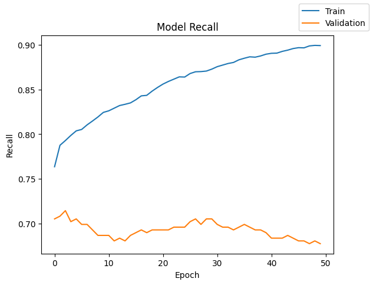

```python
# Plotting train vs validation recall
plot(history_4,'recall')
```

- Recall on the training set starts at a high value and continues to increase steadily, which means the model is learning well and finishes close to 0.90 recall.
- On the other hand, recall on the validation set starts at around 0.70 and shows fluctuations and a even a slightly downward trend from epoch onwards.
- The difference in recall between the validation and training set is significant and consistently remains large, which again indicates overfitting and how even though the training data is learning better, the model is still unable to predict well on the validation data.
- The model is likely learning noise that doesn't predict well in the validation set. It is possible that the oversampled data has amplified some data points with noise which is being learnt in the training set and not applicable to unseen data.

```python
#Predicting the results using 0.5 as a threshold.
# Predict values using the model
y_train_pred = model_4.predict(X_train)
y_val_pred = model_4.predict(X_val)

# Convert predicted value into class 1 or 0. 1 if prob > 0.5 else 0
y_train_pred = (y_train_pred > 0.5)
y_val_pred = (y_val_pred > 0.5)

# Calculate recall for training and validation sets
train_recall = recall_score(y_train, y_train_pred)
val_recall = recall_score(y_val, y_val_pred)

# Print recall scores
print(f"Training Recall: {train_recall:.4f}")
print(f"Validation Recall: {val_recall:.4f}")
```

```
200/200 ━━━━━━━━━━━━━━━━━━━━ 0s 1ms/step
50/50 ━━━━━━━━━━━━━━━━━━━━ 0s 1ms/step
Training Recall: 0.8413
Validation Recall: 0.6779
```

```python
train_metric_df.loc[model_name] = recall_score(y_train, y_train_pred)
valid_metric_df.loc[model_name] = recall_score(y_val, y_val_pred)
```

```python
#classification report
cr = classification_report(y_train, y_train_pred)
print(cr)
```

```
              precision    recall  f1-score   support

           0       0.96      0.87      0.91      5096
           1       0.63      0.84      0.72      1304

    accuracy                           0.87      6400
   macro avg       0.79      0.86      0.82      6400
weighted avg       0.89      0.87      0.87      6400
```

```python
#classification report
cr=classification_report(y_val, y_val_pred)
print(cr)
```

```
              precision    recall  f1-score   support

           0       0.91      0.82      0.86      1274
           1       0.49      0.68      0.57       326

    accuracy                           0.79      1600
   macro avg       0.70      0.75      0.71      1600
weighted avg       0.82      0.79      0.80      1600
```

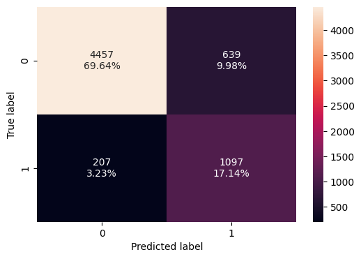

```python
make_confusion_matrix(y_train, y_train_pred)
```

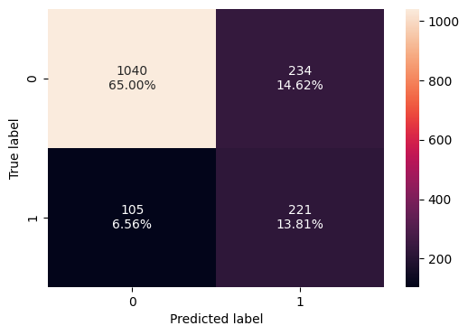

```python
make_confusion_matrix(y_val, y_val_pred)
```

- The neural network with Adam optimizer with SMOTE oversampling learnt and generalized well for the training set, reaching the point of overfitting and not able to replicate the good performance in the validation dataset.
- Though the overall recall is in a much higher range (0.70 - 0.90), the difference in the recall between training and validation data implies overfitting which means this model is not useful to predict on unseen data.
- We can truly regularization techniques like Dropout to help in addition to the balancing method.

### Neural Network with Balanced Data (by applying SMOTE), Adam Optimizer, and Dropout

```python
backend.clear_session()
#Fixing the seed for random number generators so that we can ensure we receive the same output everytime
np.random.seed(1)
random.seed(1)
tf.random.set_seed(1)

model_name = "NN with SMOTE, Adam and Dropout"

dropout_rate = 0.5
```

```python
#Initializing the neural network
model_5 = Sequential()

# Adding the input layer with 128 neurons and relu as activation function
model_5.add(Dense(64, activation='relu', input_dim = X_train_smote.shape[1]))

# Adding a dropout layer
model_5.add(Dropout(dropout_rate))

# Adding a hidden layer with 32 neurons and relu as activation function
model_5.add(Dense(32, activation='relu'))

# Adding a dropout layer
model_5.add(Dropout(dropout_rate))

# Output layer with 1 neuron for binary classification
model_5.add(Dense(1, activation = 'sigmoid'))
```

```python
model_5.summary()
```

```
Model: "sequential"
```

```
┏━━━━━━━━━━━━━━━━━━━━━━━━━━━━━━━━━━━━━━┳━━━━━━━━━━━━━━━━━━━━━━━━━━━━━┳━━━━━━━━━━━━━━━━━┓
┃ Layer (type)                         ┃ Output Shape                ┃         Param # ┃
┡━━━━━━━━━━━━━━━━━━━━━━━━━━━━━━━━━━━━━━╇━━━━━━━━━━━━━━━━━━━━━━━━━━━━━╇━━━━━━━━━━━━━━━━━┩
│ dense (Dense)                        │ (None, 64)                  │             768 │
├──────────────────────────────────────┼─────────────────────────────┼─────────────────┤
│ dropout (Dropout)                    │ (None, 64)                  │               0 │
├──────────────────────────────────────┼─────────────────────────────┼─────────────────┤
│ dense_1 (Dense)                      │ (None, 32)                  │           2,080 │
├──────────────────────────────────────┼─────────────────────────────┼─────────────────┤
│ dropout_1 (Dropout)                  │ (None, 32)                  │               0 │
├──────────────────────────────────────┼─────────────────────────────┼─────────────────┤
│ dense_2 (Dense)                      │ (None, 1)                   │              33 │
└──────────────────────────────────────┴─────────────────────────────┴─────────────────┘
```

```
 Total params: 2,881 (11.25 KB)
```

```
 Trainable params: 2,881 (11.25 KB)
```

```
 Non-trainable params: 0 (0.00 B)
```

```python
adam_optimizer = keras.optimizers.Adam()
model_5.compile(loss='binary_crossentropy', optimizer=adam_optimizer, metrics=[metric])
```

```python
start = time.time()
history_5 = model_5.fit(X_train_smote, y_train_smote, validation_data=(X_val,y_val) , batch_size=64, epochs=50)
end=time.time()
```

```
160/160 ━━━━━━━━━━━━━━━━━━━━ 5s 7ms/step - loss: 0.6979 - recall: 0.6463 - val_loss: 0.5711 - val_recall: 0.6902
160/160 ━━━━━━━━━━━━━━━━━━━━ 1s 4ms/step - loss: 0.6080 - recall: 0.6909 - val_loss: 0.5120 - val_recall: 0.7086
160/160 ━━━━━━━━━━━━━━━━━━━━ 2s 6ms/step - loss: 0.5718 - recall: 0.7053 - val_loss: 0.4860 - val_recall: 0.7209
160/160 ━━━━━━━━━━━━━━━━━━━━ 1s 7ms/step - loss: 0.5421 - recall: 0.7253 - val_loss: 0.4675 - val_recall: 0.7239
160/160 ━━━━━━━━━━━━━━━━━━━━ 1s 7ms/step - loss: 0.5275 - recall: 0.7339 - val_loss: 0.4628 - val_recall: 0.7270
160/160 ━━━━━━━━━━━━━━━━━━━━ 1s 5ms/step - loss: 0.5134 - recall: 0.7477 - val_loss: 0.4477 - val_recall: 0.7117
160/160 ━━━━━━━━━━━━━━━━━━━━ 1s 7ms/step - loss: 0.4959 - recall: 0.7406 - val_loss: 0.4453 - val_recall: 0.6994
160/160 ━━━━━━━━━━━━━━━━━━━━ 1s 6ms/step - loss: 0.4968 - recall: 0.7430 - val_loss: 0.4431 - val_recall: 0.7025
160/160 ━━━━━━━━━━━━━━━━━━━━ 2s 10ms/step - loss: 0.4885 - recall: 0.7477 - val_loss: 0.4441 - val_recall: 0.7055
160/160 ━━━━━━━━━━━━━━━━━━━━ 3s 13ms/step - loss: 0.4856 - recall: 0.7508 - val_loss: 0.4368 - val_recall: 0.7055
160/160 ━━━━━━━━━━━━━━━━━━━━ 1s 5ms/step - loss: 0.4821 - recall: 0.7549 - val_loss: 0.4369 - val_recall: 0.7025
160/160 ━━━━━━━━━━━━━━━━━━━━ 1s 6ms/step - loss: 0.4784 - recall: 0.7539 - val_loss: 0.4335 - val_recall: 0.6933
160/160 ━━━━━━━━━━━━━━━━━━━━ 1s 5ms/step - loss: 0.4732 - recall: 0.7484 - val_loss: 0.4305 - val_recall: 0.6810
160/160 ━━━━━━━━━━━━━━━━━━━━ 1s 6ms/step - loss: 0.4731 - recall: 0.7561 - val_loss: 0.4287 - val_recall: 0.6779
160/160 ━━━━━━━━━━━━━━━━━━━━ 1s 4ms/step - loss: 0.4677 - recall: 0.7477 - val_loss: 0.4357 - val_recall: 0.6902
160/160 ━━━━━━━━━━━━━━━━━━━━ 1s 5ms/step - loss: 0.4650 - recall: 0.7591 - val_loss: 0.4288 - val_recall: 0.6840
160/160 ━━━━━━━━━━━━━━━━━━━━ 1s 6ms/step - loss: 0.4618 - recall: 0.7615 - val_loss: 0.4251 - val_recall: 0.6748
160/160 ━━━━━━━━━━━━━━━━━━━━ 2s 7ms/step - loss: 0.4624 - recall: 0.7632 - val_loss: 0.4243 - val_recall: 0.6840
160/160 ━━━━━━━━━━━━━━━━━━━━ 2s 10ms/step - loss: 0.4632 - recall: 0.7609 - val_loss: 0.4265 - val_recall: 0.6871
160/160 ━━━━━━━━━━━━━━━━━━━━ 2s 7ms/step - loss: 0.4551 - recall: 0.7686 - val_loss: 0.4204 - val_recall: 0.6810
160/160 ━━━━━━━━━━━━━━━━━━━━ 2s 9ms/step - loss: 0.4618 - recall: 0.7563 - val_loss: 0.4248 - val_recall: 0.6748
160/160 ━━━━━━━━━━━━━━━━━━━━ 1s 6ms/step - loss: 0.4621 - recall: 0.7719 - val_loss: 0.4256 - val_recall: 0.6840
160/160 ━━━━━━━━━━━━━━━━━━━━ 1s 6ms/step - loss: 0.4592 - recall: 0.7678 - val_loss: 0.4264 - val_recall: 0.6933
160/160 ━━━━━━━━━━━━━━━━━━━━ 1s 4ms/step - loss: 0.4562 - recall: 0.7665 - val_loss: 0.4292 - val_recall: 0.6810
160/160 ━━━━━━━━━━━━━━━━━━━━ 1s 2ms/step - loss: 0.4486 - recall: 0.7679 - val_loss: 0.4237 - val_recall: 0.6718
160/160 ━━━━━━━━━━━━━━━━━━━━ 1s 2ms/step - loss: 0.4569 - recall: 0.7685 - val_loss: 0.4240 - val_recall: 0.6748
160/160 ━━━━━━━━━━━━━━━━━━━━ 0s 2ms/step - loss: 0.4562 - recall: 0.7578 - val_loss: 0.4217 - val_recall: 0.6687
160/160 ━━━━━━━━━━━━━━━━━━━━ 1s 3ms/step - loss: 0.4533 - recall: 0.7579 - val_loss: 0.4206 - val_recall: 0.6687
160/160 ━━━━━━━━━━━━━━━━━━━━ 0s 3ms/step - loss: 0.4494 - recall: 0.7654 - val_loss: 0.4215 - val_recall: 0.6687
160/160 ━━━━━━━━━━━━━━━━━━━━ 1s 3ms/step - loss: 0.4477 - recall: 0.7725 - val_loss: 0.4213 - val_recall: 0.6687
160/160 ━━━━━━━━━━━━━━━━━━━━ 0s 3ms/step - loss: 0.4476 - recall: 0.7637 - val_loss: 0.4232 - val_recall: 0.6748
160/160 ━━━━━━━━━━━━━━━━━━━━ 0s 3ms/step - loss: 0.4429 - recall: 0.7699 - val_loss: 0.4232 - val_recall: 0.6718
160/160 ━━━━━━━━━━━━━━━━━━━━ 0s 3ms/step - loss: 0.4471 - recall: 0.7646 - val_loss: 0.4206 - val_recall: 0.6718
160/160 ━━━━━━━━━━━━━━━━━━━━ 0s 3ms/step - loss: 0.4426 - recall: 0.7572 - val_loss: 0.4208 - val_recall: 0.6718
160/160 ━━━━━━━━━━━━━━━━━━━━ 0s 3ms/step - loss: 0.4518 - recall: 0.7607 - val_loss: 0.4246 - val_recall: 0.6748
160/160 ━━━━━━━━━━━━━━━━━━━━ 0s 3ms/step - loss: 0.4397 - recall: 0.7804 - val_loss: 0.4246 - val_recall: 0.6779
160/160 ━━━━━━━━━━━━━━━━━━━━ 1s 4ms/step - loss: 0.4362 - recall: 0.7803 - val_loss: 0.4278 - val_recall: 0.6810
160/160 ━━━━━━━━━━━━━━━━━━━━ 1s 4ms/step - loss: 0.4402 - recall: 0.7796 - val_loss: 0.4210 - val_recall: 0.6779
160/160 ━━━━━━━━━━━━━━━━━━━━ 1s 4ms/step - loss: 0.4398 - recall: 0.7733 - val_loss: 0.4218 - val_recall: 0.6748
160/160 ━━━━━━━━━━━━━━━━━━━━ 1s 4ms/step - loss: 0.4497 - recall: 0.7593 - val_loss: 0.4208 - val_recall: 0.6718
160/160 ━━━━━━━━━━━━━━━━━━━━ 1s 3ms/step - loss: 0.4426 - recall: 0.7645 - val_loss: 0.4178 - val_recall: 0.6779
160/160 ━━━━━━━━━━━━━━━━━━━━ 0s 2ms/step - loss: 0.4408 - recall: 0.7647 - val_loss: 0.4159 - val_recall: 0.6687
160/160 ━━━━━━━━━━━━━━━━━━━━ 1s 3ms/step - loss: 0.4417 - recall: 0.7700 - val_loss: 0.4211 - val_recall: 0.6779
160/160 ━━━━━━━━━━━━━━━━━━━━ 0s 3ms/step - loss: 0.4397 - recall: 0.7782 - val_loss: 0.4178 - val_recall: 0.6810
160/160 ━━━━━━━━━━━━━━━━━━━━ 0s 3ms/step - loss: 0.4354 - recall: 0.7763 - val_loss: 0.4205 - val_recall: 0.6810
160/160 ━━━━━━━━━━━━━━━━━━━━ 1s 3ms/step - loss: 0.4342 - recall: 0.7748 - val_loss: 0.4218 - val_recall: 0.6902
160/160 ━━━━━━━━━━━━━━━━━━━━ 0s 3ms/step - loss: 0.4353 - recall: 0.7781 - val_loss: 0.4221 - val_recall: 0.6840
160/160 ━━━━━━━━━━━━━━━━━━━━ 1s 3ms/step - loss: 0.4340 - recall: 0.7743 - val_loss: 0.4214 - val_recall: 0.6810
160/160 ━━━━━━━━━━━━━━━━━━━━ 1s 2ms/step - loss: 0.4318 - recall: 0.7738 - val_loss: 0.4254 - val_recall: 0.6871
160/160 ━━━━━━━━━━━━━━━━━━━━ 0s 3ms/step - loss: 0.4348 - recall: 0.7803 - val_loss: 0.4283 - val_recall: 0.6933
```

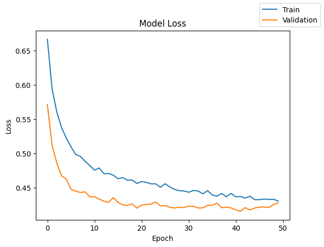

```python
# Plotting train vs validation loss
plot(history_5,'loss')
```

- The training loss (blue line) decreases rapidly until around epoch number 10 and then decreases more slowly until it reaches a minimum, indicating that the model is continuously learning from the data.
- The validation loss (orange line) decreases initially very similarly to the training data and then decreases steadily throughout the epochs with slight fluctuations.
- The model is performing well on training data and validation data, and both converge fairly quickly and even end up at almost the same loss at the end of training.

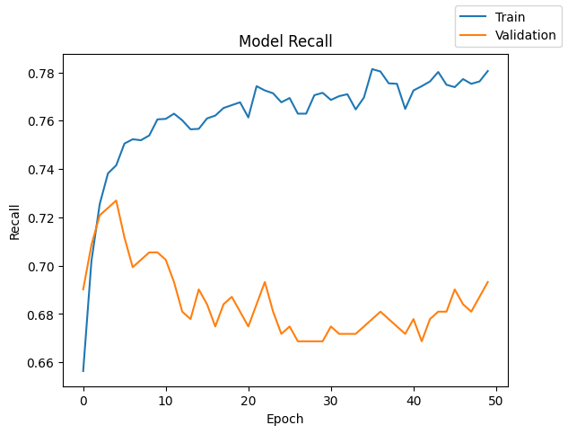

```python
# Plotting train vs validation recall
plot(history_5,'recall')
```

- Recall on the training set starts at around 0.66 and increases rapidly in the first 10 epochs and then increases more slowly and with fluctuations until it reaches a recall of around 0.78.
- Recall on the validation dataset also increases initially but then continues to fall and stabilizes around 0.69.
- The model is not performing as well on unseen data and it is on training data, and the fluctuations in validation recall indicates that the model is unable to generalize well enough from the traiing to validation set.
- The model is likely overfitting, however it is an improvement from the previous model with much higher overfitting.

```python
#Predicting the results using 0.5 as a threshold.
# Predict values using the model
y_train_pred = model_5.predict(X_train)
y_val_pred = model_5.predict(X_val)

# Convert predicted value into class 1 or 0. 1 if prob > 0.5 else 0
y_train_pred = (y_train_pred > 0.5)
y_val_pred = (y_val_pred > 0.5)

# Calculate recall for training and validation sets
train_recall = recall_score(y_train, y_train_pred)
val_recall = recall_score(y_val, y_val_pred)

# Print recall scores
print(f"Training Recall: {train_recall:.4f}")
print(f"Validation Recall: {val_recall:.4f}")
```

```
200/200 ━━━━━━━━━━━━━━━━━━━━ 1s 2ms/step
50/50 ━━━━━━━━━━━━━━━━━━━━ 0s 1ms/step
Training Recall: 0.7285
Validation Recall: 0.6933
```

```python
train_metric_df.loc[model_name] = recall_score(y_train, y_train_pred)
valid_metric_df.loc[model_name] = recall_score(y_val, y_val_pred)
```

```python
#classification report
cr = classification_report(y_train, y_train_pred)
print(cr)
```

[output not shown]

```python
#classification report
cr=classification_report(y_val, y_val_pred)
print(cr)
```

```
              precision    recall  f1-score   support

           0       0.92      0.85      0.88      1274
           1       0.54      0.69      0.61       326

    accuracy                           0.82      1600
   macro avg       0.73      0.77      0.74      1600
weighted avg       0.84      0.82      0.82      1600
```

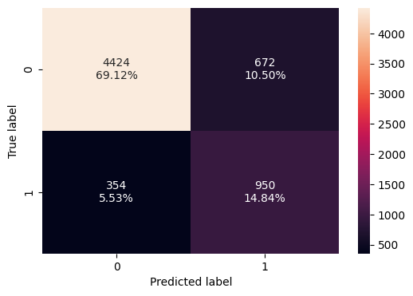

```python
make_confusion_matrix(y_train, y_train_pred)
```

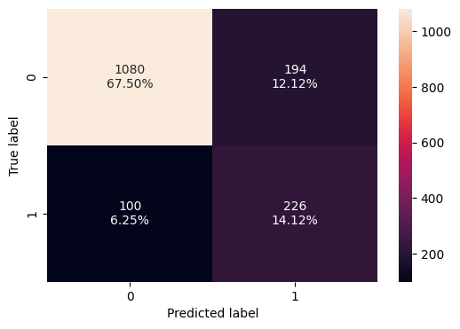

```python
make_confusion_matrix(y_val, y_val_pred)
```

- The neural network with Adam optimizer with SMOTE oversampling and Dropout learnt and generalized well for the training set, and showed stable learning and loss minimization. However, the recall on the validation dataset is unstable and not showing consistency which means the model has some level of overfitting and isn't able to perform well on unseen data.
- The lack of upward trend and the difference in recall between training and validation set is of concern. Despite that, the average recall between the two datasets is fairly similar and the model is an improvement over the previous one without dropout.

## Model Performance Comparison and Final Model Selection

```python
# Summarize all 6 models into a table and compare recall in training and validation sets
train_metric_df.columns = ['train_recall']
valid_metric_df.columns = ['valid_recall']
comparison_df = pd.concat([train_metric_df, valid_metric_df], axis=1)
comparison_df
```

|  | train_recall | valid_recall |
| --- | --- | --- |
| NN with SGD | 0.471626 | 0.438650 |
| NN with Adam | 0.519939 | 0.435583 |
| NN with Adam and Dropout | 0.482362 | 0.444785 |
| NN with SMOTE and SGD | 0.746166 | 0.696319 |
| NN with SMOTE and Adam | 0.841258 | 0.677914 |
| NN with SMOTE, Adam and Dropout | 0.728528 | 0.693252 |

Below is a concise summary of comparison of recalls of all the models between train and validaton datasets

Considering all the recall comparisons here and also the recall over epochs, the chosen model is **NN with SMOTE and SGD** because it is good at generalizing, isn't overfitting, and despite the small difference between train and validation recall, the learning and predicting power is much more stable.

```python
#Predict on test data using 0.5 as threshold
y_test_pred = model_3.predict(X_test)

# Convert predicted value into class 1 or 0. 1 if prob > 0.5 else 0
y_test_pred = (y_test_pred > 0.5)

# Calculate recall for training and validation sets
test_recall = recall_score(y_test, y_test_pred)

# Print recall scores
print(f"Test Recall: {test_recall:.4f}")
```

```
63/63 ━━━━━━━━━━━━━━━━━━━━ 0s 3ms/step
Test Recall: 0.6757
```

- Prediction on the unseen data gives us a very reasonable recall of 0.67, which means that the model correctly identifies about 67% of the churners in the unseen data.
- This is a good recall score and a good trade off to have a moderate recall score but a consistent one that can generalize well enough on unseen data.

## Actionable Insights and Business Recommendations

Based on the exploratory data analysis, model building, model performance improvement attempts, and overall analysis, the following are recommendations for the business:

- With a recall of about 0.67 on unseen data, the model correctly identifies 67% of the customers that churn. The business must focus on this group to implement retention strategies like targeted marketing and focused customer service because these customers are likely to churn.
- Being able to identify a large number of customers likely to churn means the business can further study these customers and their characteristics, such as tenure, activity, and account balance, for personalized retention strategies and possibly even clustering analysis.
- Further areas of exploration for the model can include experimenting with other optimization strategies, such as L1/L2 regularization, weight initialization, etc., to further reduce overfitting and potentially improve recall.
- It is worthwhile investing in continuing to collect data and more features for further analysis to rectify the model's current limitations. Exploring other features, such as the custom satisfaction score from the survey, activity in the last quarter, the number of points of contact with the bank, etc., may improve the model's generalization power.
- Since customers' behaviour is likely to change over time, it is important to continuously retrain the model at regular intervals with updated data and maintain it up to date with new customer behaviour so that it continues to be useful and relevant.

Based on these insights, the company can implement particular actions to enhance retention rates and reduce churn and also develop the predictive model in the long term. From the technology perspective, a data-driven approach and constant improvement of the model will help the company proactively implement measures against churn and retain the existing customer base.

Power Ahead ___